# MotCog_w_ConSupp

William Staples

2023-03-14

## Project Overview

### Pilot Study (Study 1)

- Manipulate actor political affiliation via vignettes.
- Assessed participant political affiliation with slider only.
- Used 17 item MJI.

### Replication 1 (Study 2)

- Manipulate actor political affiliation via vignettes.
- Assessed participant political affiliation with slider only.
- Used 17 item MJI.

### Replication 2 (Study 3)

- Manipulate actor political “team” affiliation via twitter posts.
- Assessed participant political orientation with a slider and the ABPC.
- Used 2 Factor MJI

### Replication 3 (Study 4)

- Doubled the sample size form study 3
- Manipulate actor political “team” affiliation via twitter posts.
- Assessed participant political orientation with a slider and the ABPC.
- Used 2 Factor MJI

### Combined Study 3 & Study 4

- Doubled data from study 3 and study 4
- Manipulate actor political “team” affiliation via twitter posts.
- Assessed participant political orientation with a slider and the ABPC.
- Used 2 Factor MJI

## t-test polornt for both studies

```
##
##  Welch Two Sample t-test
##
## data:  dat3$polornt and dat4$polornt
## t = -1.3698, df = 679.44, p-value = 0.1712
## alternative hypothesis: true difference in means is not equal to 0
## 95 percent confidence interval:
##  -5.6138400  0.9998039
## sample estimates:
## mean of x mean of y
##  36.30867  38.61569
```

## Demographics

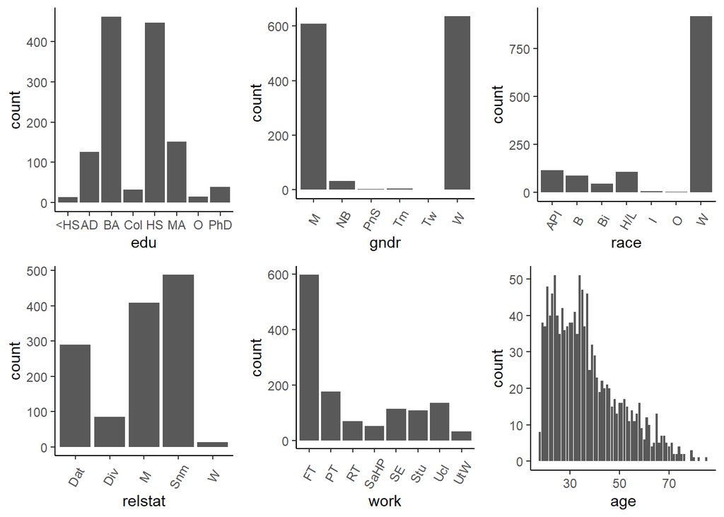

## Frequency statistics

Intent conditions and political orientation (as measured by self-report slider)

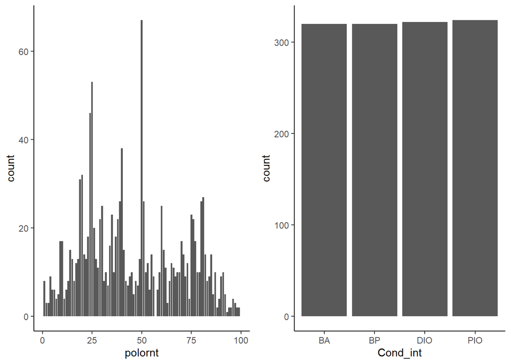

# MJI

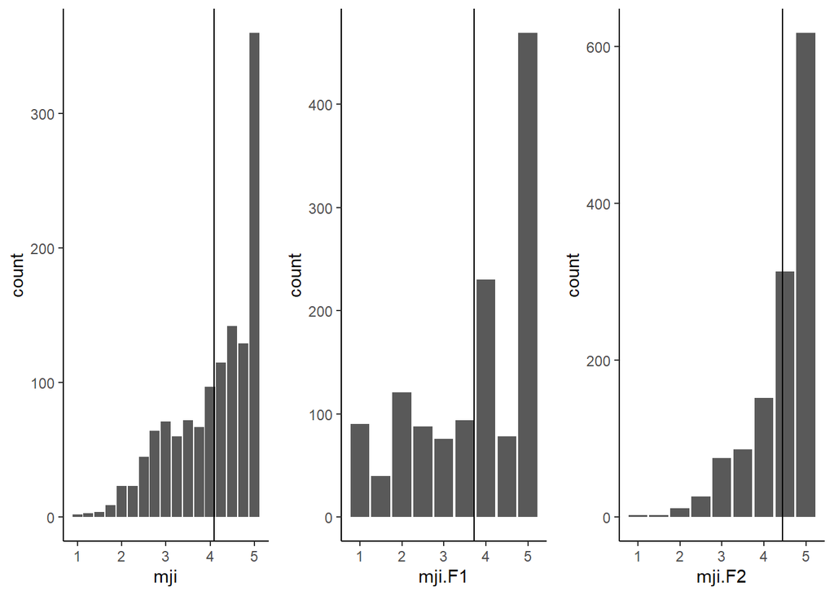

# ABPC

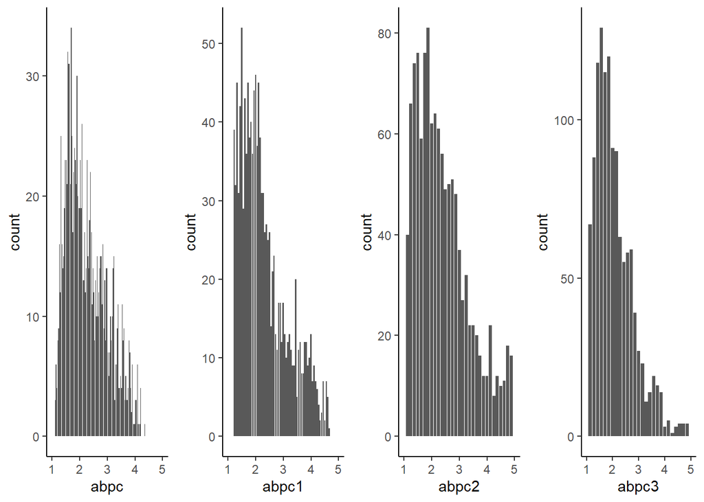

# Skewness & Kurtosis

### Skewness (without transformation)

MJI

```
## [1] -0.8330352
```

MJI F1

```
## [1] -0.6918166
```

MJI F2

```
## [1] -1.548989
```

### Log Transofrmation

MJI

```
## [1] -1.432237
```

MJI F1

```
## [1] -1.306361
```

MJI F2

```
## [1] -2.528657
```

### Square Transformation

MJI

```
## [1] -0.4904071
```

MJI F1

```
## [1] -0.3017756
```

MJI F2

```
## [1] -1.106368
```

### Kurtosis (without transformation)

MJI

```
## [1] -0.2713927
```

MJI F1

```
## [1] -0.8130067
```

MJI F2

```
## [1] 2.236776
```

### Log Transofrmation

MJI

```
## [1] 2.183295
```

MJI F1

```
## [1] 0.748173
```

MJI F2

```
## [1] 9.557597
```

### Square Transformation

MJI

```
## [1] -1.034542
```

MJI F1

```
## [1] -1.38227
```

MJI F2

```
## [1] 0.3085802
```

## MJI

Full index

```
##
## Cronbach's alpha for the 'mji.a' data-set
##
## Items: 4
## Sample units: 1286
## alpha: 0.822
```

Factor 1

```
##
## Cronbach's alpha for the 'mjif1.a' data-set
##
## Items: 2
## Sample units: 1286
## alpha: 0.921
```

Factor 2

```
##
## Cronbach's alpha for the 'mjif2.a' data-set
##
## Items: 2
## Sample units: 1286
## alpha: 0.721
```

## MJI factor 2 has poor internal consistency, lets find our why.

- Mean MJI item F1.1 = 3.8079316
  - “To what extent were JG’s actions intentional?”
- Mean MJI item F1.2 = 3.6337481
  - “To what extent can one say that JG did what they did on purpose?”
- Mean MJI item F2.1 = 2.8522551
  - “How positively should JG be judged?”
- Mean MJI item F2.2 = 4.2534992
  - “How negatively should JG be judged?”
- Mean MJI item F2.3 = 4.6454121
  - “How much blame should JG receive as a result of their actions?”
- Mean MJI item F2.4 = 2.9844479
  - “Even if no one ever finds out what they did, JG will get what they deserve.”

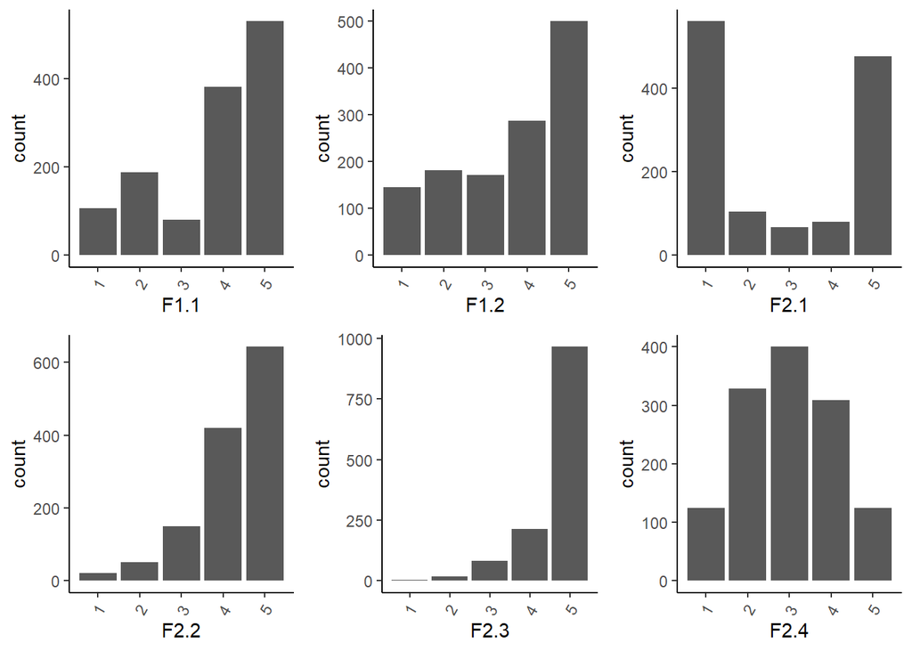

F2.1/F2.4 seem to be the issue. Lets investigate

Visualize Correlation Matrix

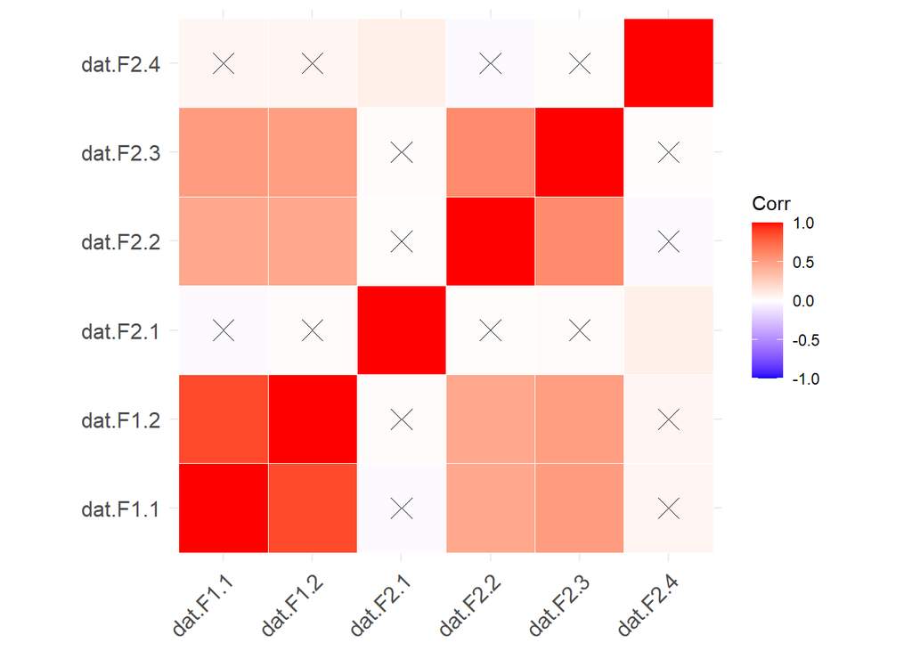

Conclusion: There is very little item intercorrelation for F2.1 and F2.4 with the remainder of the items.

- The items “How positively should JG be judged?” and “Even if no one ever finds out what they did, JG will get what they deserve.” seem to be problematic for our study.
  - My guess is that F2.1 was misinterpreted by some respondents (bimodal distribution), and F2.4 is an assessment of the respondents ‘Just World’ beliefs, not anything to do with the respondents perception of actor moral culpability. For this reason I will remove these items from the analyses.

## ABPC

Full measure

```
##
## Cronbach's alpha for the 'abpc.all' data-set
##
## Items: 33
## Sample units: 1286
## alpha: 0.944
```

Subscale 1: Libertarian Independence

```
##
## Cronbach's alpha for the 'abpc.scale1' data-set
##
## Items: 18
## Sample units: 1286
## alpha: 0.931
```

Subscale 2: Religious Traditionalism

```
##
## Cronbach's alpha for the 'abpc.scale2' data-set
##
## Items: 8
## Sample units: 1286
## alpha: 0.908
```

Subscale 3: Ethnic Separateness

```
##
## Cronbach's alpha for the 'abpc.scale3' data-set
##
## Items: 7
## Sample units: 1286
## alpha: 0.816
```

## Assumption Check: 2-Factor MJI

It is assumed that the MJI is divisible into 2 factors, F1 is composed of items related to the actors intentionality (items F1.1 & F1.2), F2 is composed of more emotional/valence related items (items F2.1, F2.2, F2.3, F2.4).

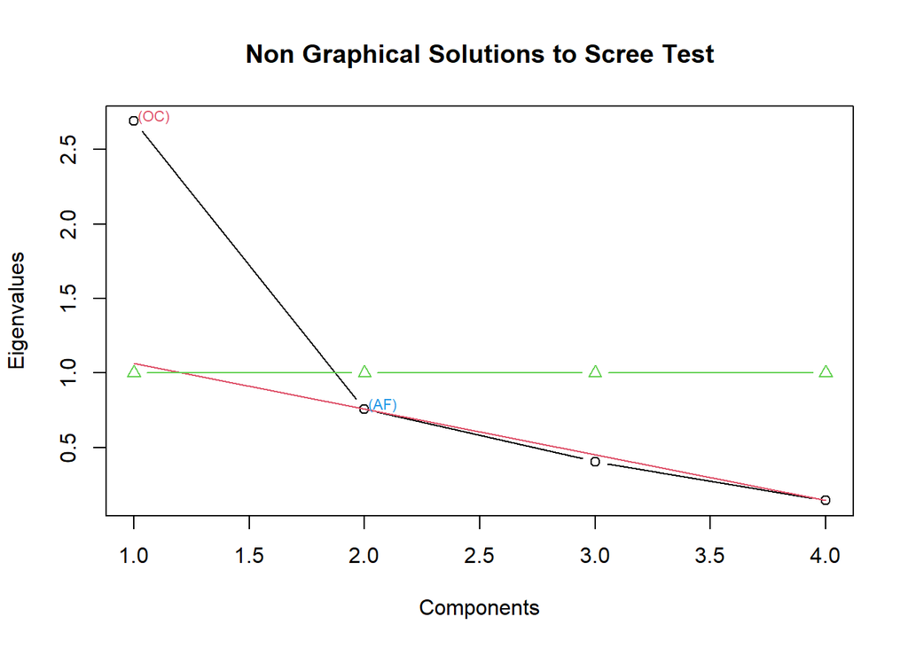

### Eigenvalues

```
## [1] 2.6895954 0.7589790 0.4063124 0.1451132
```

### Factor Loadings

```
##
## Call:
## factanal(x = dat.mji.full, factors = 2, rotation = "promax")
##
## Uniquenesses:
## dat.F1.1 dat.F1.2 dat.F2.1 dat.F2.2 dat.F2.3 dat.F2.4
##     0.00     0.25     1.00     0.41     0.40     0.99
##
## Loadings:
##          Factor1 Factor2
## dat.F1.2  0.68    0.58
## dat.F2.2  0.76
## dat.F2.3  0.77
## dat.F1.1  0.70    0.76
## dat.F2.1
## dat.F2.4
##
##                Factor1 Factor2
## SS loadings       2.12    0.93
## Proportion Var    0.35    0.16
## Cumulative Var    0.35    0.51
##
## Factor Correlations:
##         Factor1 Factor2
## Factor1   1.000  -0.065
## Factor2  -0.065   1.000
##
## Test of the hypothesis that 2 factors are sufficient.
## The chi square statistic is 16.23 on 4 degrees of freedom.
## The p-value is 0.00272
```

## Assumption Check: 3-Factor ABPC

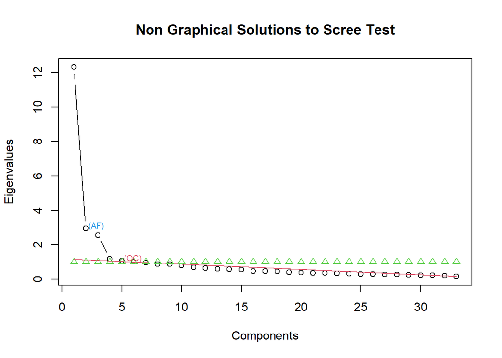

### EigenValues

```
##  [1] 12.3438629  2.9420824  2.5623121  1.1764560  1.0570310  0.9975810
##  [7]  0.9418845  0.8667022  0.8561323  0.7766746  0.6691843  0.6153389
## [13]  0.5758154  0.5638482  0.5367507  0.4616585  0.4606378  0.4319420
## [19]  0.3960829  0.3741514  0.3490899  0.3459333  0.3193272  0.3032350
## [25]  0.2792325  0.2719829  0.2656783  0.2520980  0.2337943  0.2197935
## [31]  0.2100491  0.2009696  0.1426874
```

### Factor Loadings

```
##
## Call:
## factanal(x = dat.abpc, factors = 6, rotation = "promax")
##
## Uniquenesses:
##  dat.abpc.1  dat.abpc.2  dat.abpc.3  dat.abpc.4  dat.abpc.5  dat.abpc.6
##        0.23        0.37        0.17        0.33        0.33        0.86
##  dat.abpc.7  dat.abpc.8  dat.abpc.9 dat.abpc.10 dat.abpc.11 dat.abpc.12
##        0.92        0.26        0.36        0.50        0.59        0.48
## dat.abpc.13 dat.abpc.14 dat.abpc.15 dat.abpc.16 dat.abpc.17 dat.abpc.18
##        0.23        0.39        0.42        0.35        0.32        0.53
## dat.abpc.19 dat.abpc.20 dat.abpc.21 dat.abpc.22 dat.abpc.23 dat.abpc.24
##        0.19        0.14        0.28        0.31        0.42        0.94
## dat.abpc.25 dat.abpc.26 dat.abpc.27 dat.abpc.28 dat.abpc.29 dat.abpc.30
##        0.66        0.66        0.25        0.24        0.53        0.39
## dat.abpc.31 dat.abpc.32 dat.abpc.33
##        0.40        0.56        0.59
##
## Loadings:
##             Factor1 Factor2 Factor3 Factor4 Factor5 Factor6
## dat.abpc.4   0.61
## dat.abpc.5   0.76
## dat.abpc.8   0.95
## dat.abpc.10  0.69
## dat.abpc.12  0.67
## dat.abpc.14  0.84
## dat.abpc.15  0.73
## dat.abpc.16  0.54                    0.36
## dat.abpc.17  0.76
## dat.abpc.18  0.55
## dat.abpc.19          0.97
## dat.abpc.20          0.98
## dat.abpc.21          0.85
## dat.abpc.22          0.83
## dat.abpc.26          0.58
## dat.abpc.27                  0.90
## dat.abpc.28                  0.87
## dat.abpc.29                  0.54
## dat.abpc.30                  0.71
## dat.abpc.31                          0.74
```

[output cut: 16 more lines]

```
## Proportion Var    0.18    0.12    0.07    0.07    0.05    0.03
## Cumulative Var    0.18    0.30    0.38    0.44    0.49    0.52
##
## Factor Correlations:
##         Factor1 Factor2 Factor3 Factor4 Factor5 Factor6
## Factor1    1.00   -0.47   -0.31    0.64   -0.55   -0.67
## Factor2   -0.47    1.00    0.20   -0.37    0.33    0.54
## Factor3   -0.31    0.20    1.00   -0.16    0.28    0.50
## Factor4    0.64   -0.37   -0.16    1.00   -0.54   -0.53
## Factor5   -0.55    0.33    0.28   -0.54    1.00    0.47
## Factor6   -0.67    0.54    0.50   -0.53    0.47    1.00
##
## Test of the hypothesis that 6 factors are sufficient.
## The chi square statistic is 1293.07 on 345 degrees of freedom.
## The p-value is 1.42e-109
```

# ABPC*polornt correlation

```
##
##  Pearson's product-moment correlation
##
## data:  dat$polornt and dat$abpc
## t = 46.598, df = 1284, p-value < 2.2e-16
## alternative hypothesis: true correlation is not equal to 0
## 95 percent confidence interval:
##  0.7714846 0.8121872
## sample estimates:
##       cor
## 0.7927178
```

# Linear Modeling

## Assumption Check: Intentionality

We designs each of the 4 conditions to be more or less intentional. We assume BA is the least intentional, BP is the most intentional, and PIo and DIo are somewhere in between. The following analysis seeks to determine if that is assumption manifests in the data.

```
##               Df Sum Sq Mean Sq F value Pr(>F)
## Cond_int       3  734.4  244.79   209.9 <2e-16 ***
## Residuals   1282 1495.4    1.17
## ---
## Signif. codes:  0 '***' 0.001 '**' 0.01 '*' 0.05 '.' 0.1 ' ' 1
```

```
##   Tukey multiple comparisons of means
##     95% family-wise confidence level
##
## Fit: aov(formula = mean.mjif1 ~ Cond_int, data = dat)
##
## $Cond_int
##               diff        lwr         upr     p adj
## BP-BA    1.7718750  1.5522322  1.99151778 0.0000000
## DIO-BA  -0.1453222 -0.3646237  0.07397925 0.3216151
## PIO-BA   0.6725694  0.4536056  0.89153327 0.0000000
## DIO-BP  -1.9171972 -2.1364987 -1.69789575 0.0000000
## PIO-BP  -1.0993056 -1.3182694 -0.88034173 0.0000000
## PIO-DIO  0.8178916  0.5992702  1.03651308 0.0000000
```

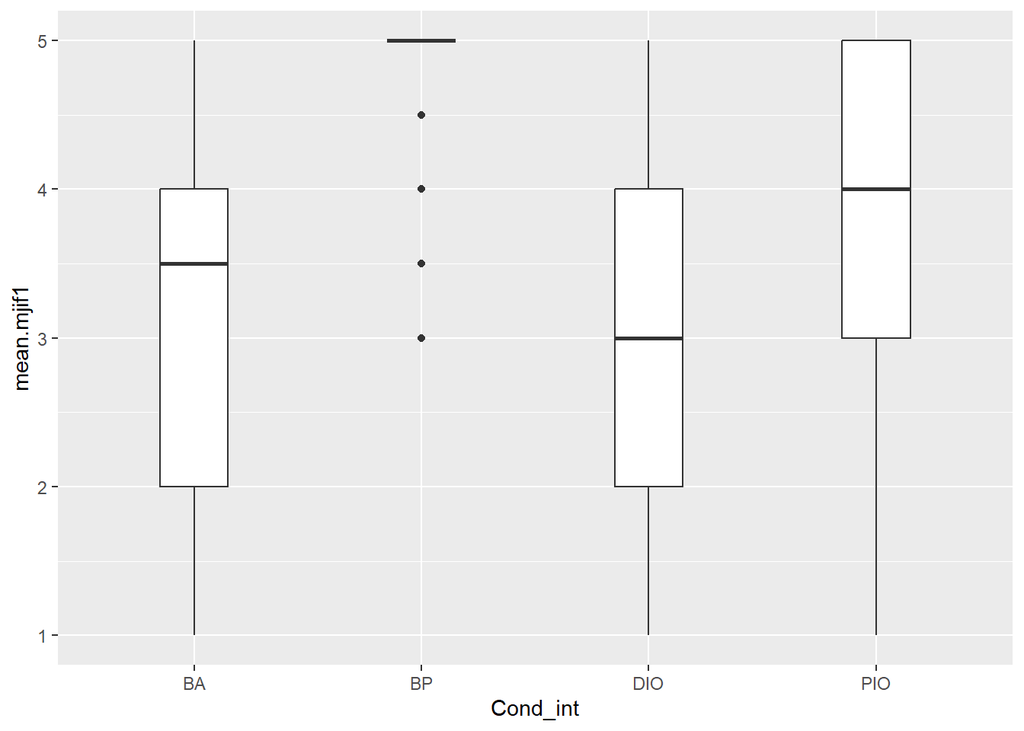

## Moderation Analysis

The goal of this analysis is to determine the moderation effect of the first MJI factor. Most of the observed effects have been in the BA condition, thus we seek to answer the question “do participants who believed the BA condition to still be highly intentional (high mji.f1 in BA condition) show a tweet*political_orientation interaction effect when compared to participants who perceive low intentionality”? We use the MJI intent factor as the moderator and the valence factor as the DV. Tweets and political orientation are inputted as predictor variables.

## Full model

```
##
## Call:
## lm(formula = mc_mjif2 ~ mc_polornt * mc_mjif1 * tweets, data = subset(dat,
##     Cond_int == "BA"))
##
## Residuals:
##     Min      1Q  Median      3Q     Max
## -1.9079 -0.4118  0.0808  0.4216  1.7337
##
## Coefficients:
##                              Estimate Std. Error t value Pr(>|t|)
## (Intercept)                  0.073237   0.062755   1.167 0.244091
## mc_polornt                   0.003741   0.002515   1.488 0.137891
## mc_mjif1                     0.344394   0.042957   8.017 2.19e-14 ***
## tweetsR                     -0.123776   0.082469  -1.501 0.134398
## mc_polornt:mc_mjif1         -0.004057   0.001767  -2.296 0.022334 *
## mc_polornt:tweetsR          -0.007194   0.003367  -2.137 0.033414 *
## mc_mjif1:tweetsR            -0.012391   0.059885  -0.207 0.836218
## mc_polornt:mc_mjif1:tweetsR  0.008676   0.002516   3.449 0.000641 ***
## ---
## Signif. codes:  0 '***' 0.001 '**' 0.01 '*' 0.05 '.' 0.1 ' ' 1
##
## Residual standard error: 0.6518 on 312 degrees of freedom
## Multiple R-squared:  0.3485, Adjusted R-squared:  0.3339
## F-statistic: 23.85 on 7 and 312 DF,  p-value: < 2.2e-16
```

### polornt = Left

```
##
## Call:
## lm(formula = mc_mjif2 ~ mc_polornt * mc_mjif1 * tweets, data = subset(dat,
##     Cond_int == "BA" & L.R == "L"))
##
## Residuals:
##     Min      1Q  Median      3Q     Max
## -1.7652 -0.4062  0.1637  0.4187  1.7737
##
## Coefficients:
##                               Estimate Std. Error t value Pr(>|t|)
## (Intercept)                 -0.0497308  0.2070875  -0.240  0.81054
## mc_polornt                  -0.0017240  0.0088929  -0.194  0.84654
## mc_mjif1                     0.3943442  0.1481239   2.662  0.00859 **
## tweetsR                      0.0452801  0.2592526   0.175  0.86158
## mc_polornt:mc_mjif1         -0.0023435  0.0067562  -0.347  0.72916
## mc_polornt:tweetsR           0.0006131  0.0115250   0.053  0.95764
## mc_mjif1:tweetsR            -0.2130757  0.2033687  -1.048  0.29641
## mc_polornt:mc_mjif1:tweetsR -0.0010596  0.0096792  -0.109  0.91297
## ---
## Signif. codes:  0 '***' 0.001 '**' 0.01 '*' 0.05 '.' 0.1 ' ' 1
##
## Residual standard error: 0.6716 on 153 degrees of freedom
## Multiple R-squared:  0.3135, Adjusted R-squared:  0.2821
## F-statistic: 9.982 on 7 and 153 DF,  p-value: 3.06e-10
```

### polornt = Right

```
##
## Call:
## lm(formula = mc_mjif2 ~ mc_polornt * mc_mjif1 * tweets, data = subset(dat,
##     Cond_int == "BA" & L.R == "R"))
##
## Residuals:
##      Min       1Q   Median       3Q      Max
## -1.72792 -0.37776  0.07396  0.36953  1.24073
##
## Coefficients:
##                               Estimate Std. Error t value Pr(>|t|)
## (Intercept)                  0.0705934  0.1407830   0.501   0.6168
## mc_polornt                   0.0042477  0.0054181   0.784   0.4343
## mc_mjif1                     0.2917376  0.0890085   3.278   0.0013 **
## tweetsR                     -0.0324208  0.1901597  -0.170   0.8649
## mc_polornt:mc_mjif1         -0.0022242  0.0034209  -0.650   0.5166
## mc_polornt:tweetsR          -0.0109315  0.0071719  -1.524   0.1295
## mc_mjif1:tweetsR            -0.0008708  0.1287016  -0.007   0.9946
## mc_polornt:mc_mjif1:tweetsR  0.0088033  0.0049163   1.791   0.0754 .
## ---
## Signif. codes:  0 '***' 0.001 '**' 0.01 '*' 0.05 '.' 0.1 ' ' 1
##
## Residual standard error: 0.6389 on 151 degrees of freedom
## Multiple R-squared:  0.4007, Adjusted R-squared:  0.373
## F-statistic: 14.43 on 7 and 151 DF,  p-value: 2.731e-14
```

A simple slopes graph for mc_polornt*mc_mjif1

Traditional simple slopes is impossible for MJI.F1 as its mean+1SD exceeds the maximum value of the MJI scale. Additionally, traditional simple slopes does not permit the use of dichotomous variables.

Instead, we can use MJI.F1 >= 4 compared to MJI.F1 < 4.

### mjif1 >= 4

```
##
## Call:
## lm(formula = mc_mjif2 ~ mc_polornt * tweets, data = subset(dat,
##     Cond_int == "BA" & mean.mjif1 >= 4))
##
## Residuals:
##     Min      1Q  Median      3Q     Max
## -1.6956 -0.2712  0.2208  0.3044  0.7302
##
## Coefficients:
##                      Estimate Std. Error t value Pr(>|t|)
## (Intercept)         0.3241615  0.0730823   4.436 2.01e-05 ***
## mc_polornt         -0.0004843  0.0027538  -0.176   0.8607
## tweetsR            -0.2063547  0.0919052  -2.245   0.0265 *
## mc_polornt:tweetsR -0.0051941  0.0036017  -1.442   0.1518
## ---
## Signif. codes:  0 '***' 0.001 '**' 0.01 '*' 0.05 '.' 0.1 ' ' 1
##
## Residual standard error: 0.4943 on 123 degrees of freedom
## Multiple R-squared:  0.07972,    Adjusted R-squared:  0.05728
## F-statistic: 3.552 on 3 and 123 DF,  p-value: 0.01648
```

### mjif1 < 4

```
##
## Call:
## lm(formula = mc_mjif2 ~ mc_polornt * tweets, data = subset(dat,
##     Cond_int == "BA" & mean.mjif1 < 4))
##
## Residuals:
##     Min      1Q  Median      3Q     Max
## -2.2422 -0.5499  0.1555  0.5759  1.4737
##
## Coefficients:
##                     Estimate Std. Error t value Pr(>|t|)
## (Intercept)        -0.416162   0.080105  -5.195 5.27e-07 ***
## mc_polornt          0.011367   0.003479   3.268 0.001288 **
## tweetsR            -0.070265   0.118653  -0.592 0.554435
## mc_polornt:tweetsR -0.018856   0.004907  -3.842 0.000166 ***
## ---
## Signif. codes:  0 '***' 0.001 '**' 0.01 '*' 0.05 '.' 0.1 ' ' 1
##
## Residual standard error: 0.8203 on 189 degrees of freedom
## Multiple R-squared:  0.0767, Adjusted R-squared:  0.06204
## F-statistic: 5.233 on 3 and 189 DF,  p-value: 0.001716
```

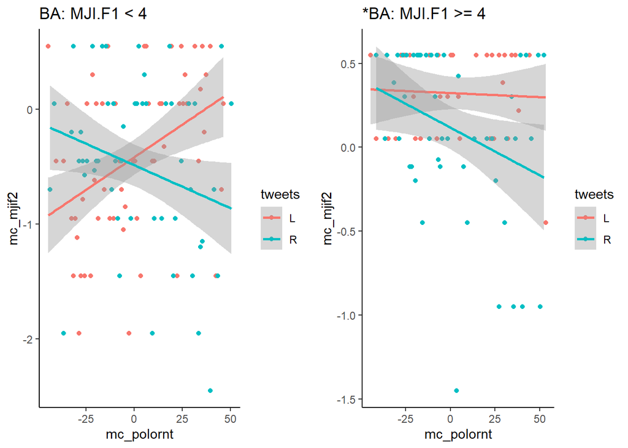

## 4-ITEM MJI - sqr transformed - Full model using ABPC as a measure of political orientation

Full cases =1286

```
##
## Call:
## lm(formula = sqr.mji ~ PI + DI + tweets + abpc + PI * DI + PI *
##     tweets + PI * abpc + DI * tweets + DI * abpc + tweets * abpc +
##     PI * DI * tweets + PI * DI * abpc + PI * tweets * abpc +
##     DI * tweets * abpc, data = dat)
##
## Residuals:
##     Min      1Q  Median      3Q     Max
## -16.077  -3.720   1.091   3.751  12.530
##
## Coefficients:
##                  Estimate Std. Error t value Pr(>|t|)
## (Intercept)        9.0210     1.3899   6.491 1.22e-10 ***
## PI1                5.7699     1.8143   3.180  0.00151 **
## DI1                2.8534     1.8301   1.559  0.11922
## tweetsR           10.1570     1.8176   5.588 2.81e-08 ***
## abpc               2.0697     0.5585   3.706  0.00022 ***
## PI1:DI1            4.5520     2.1427   2.124  0.03383 *
## PI1:tweetsR       -3.6502     2.1637  -1.687  0.09185 .
## PI1:abpc          -0.9801     0.7378  -1.328  0.18431
## DI1:tweetsR       -5.8636     2.1470  -2.731  0.00640 **
## DI1:abpc          -0.9055     0.7451  -1.215  0.22450
## tweetsR:abpc      -3.8804     0.7427  -5.225 2.04e-07 ***
## PI1:DI1:tweetsR    1.3106     1.2542   1.045  0.29627
## PI1:DI1:abpc       0.4079     0.8643   0.472  0.63703
## PI1:tweetsR:abpc   1.4767     0.8640   1.709  0.08768 .
## DI1:tweetsR:abpc   1.6460     0.8637   1.906  0.05692 .
## ---
## Signif. codes:  0 '***' 0.001 '**' 0.01 '*' 0.05 '.' 0.1 ' ' 1
##
## Residual standard error: 5.596 on 1271 degrees of freedom
## Multiple R-squared:  0.3318, Adjusted R-squared:  0.3244
## F-statistic: 45.07 on 14 and 1271 DF,  p-value: < 2.2e-16
```

#### Residual Density and Q-Q plots

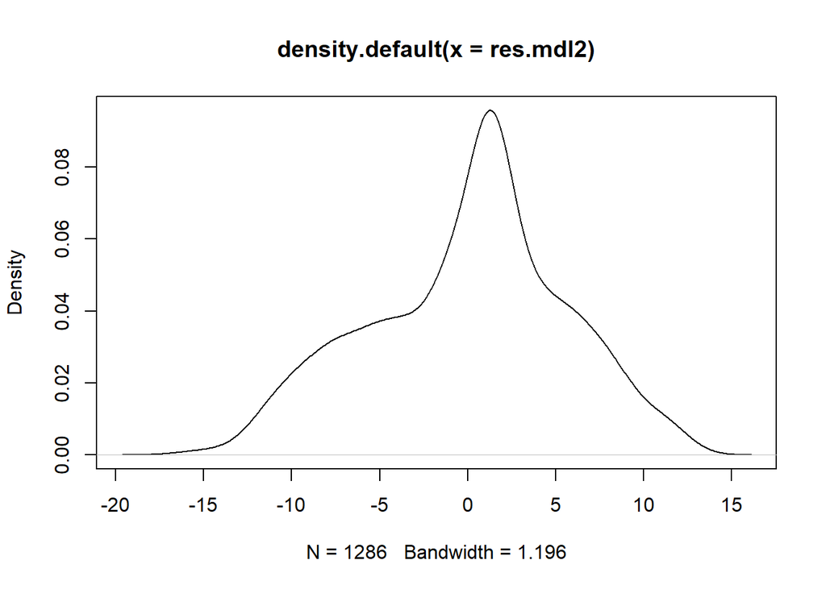

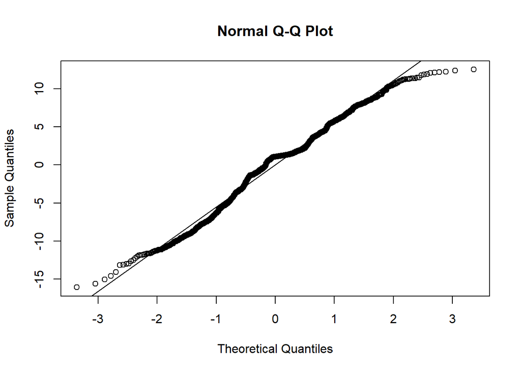

#### ANOVA and Tukey’s on model residuals

```
##               Df Sum Sq Mean Sq F value Pr(>F)
## Cond_int       3   2953   984.4   111.1 <2e-16 ***
## Residuals   1282  11358     8.9
## ---
## Signif. codes:  0 '***' 0.001 '**' 0.01 '*' 0.05 '.' 0.1 ' ' 1
```

```
##   Tukey multiple comparisons of means
##     95% family-wise confidence level
##
## Fit: aov(formula = resids.abs.mdl2 ~ Cond_int, data = dat)
##
## $Cond_int
##                diff        lwr        upr     p adj
## BP-BA   -3.42662176 -4.0319550 -2.8212885 0.0000000
## DIO-BA   0.12609151 -0.4783010  0.7304840 0.9500871
## PIO-BA   0.10343376 -0.5000282  0.7068958 0.9713496
## DIO-BP   3.55271327  2.9483208  4.1571058 0.0000000
## PIO-BP   3.53005551  2.9265935  4.1335175 0.0000000
## PIO-DIO -0.02265776 -0.6251762  0.5798606 0.9996758
```

### Regression Coefficients

```
##
## Call:
## lm(formula = sqr.mji ~ PI + DI + tweets + abpc + PI * DI + PI *
##     tweets + PI * abpc + DI * tweets + DI * abpc + tweets * abpc +
##     PI * DI * tweets + PI * DI * abpc + PI * tweets * abpc +
##     DI * tweets * abpc, data = dat)
##
## Standardized Coefficients::
##      (Intercept)              PI1              DI1          tweetsR
##               NA       0.42393033       0.20964768       0.74626901
##             abpc          PI1:DI1      PI1:tweetsR         PI1:abpc
##       0.22102500       0.28918778      -0.23285691      -0.17953703
##      DI1:tweetsR         DI1:abpc     tweetsR:abpc  PI1:DI1:tweetsR
##      -0.37173206      -0.16396374      -0.71045311       0.06457079
##     PI1:DI1:abpc PI1:tweetsR:abpc DI1:tweetsR:abpc
##       0.06248659       0.23297077       0.25327025
```

Graphing Effects

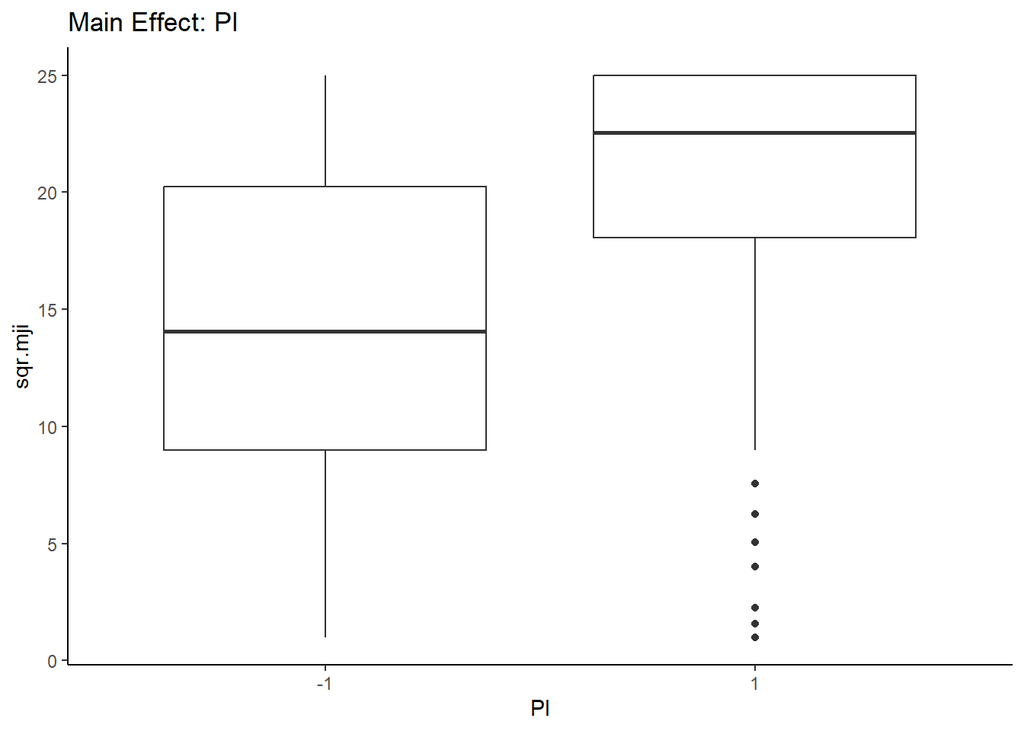

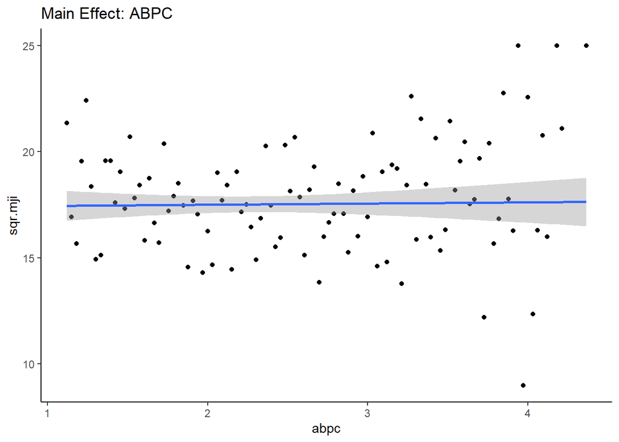

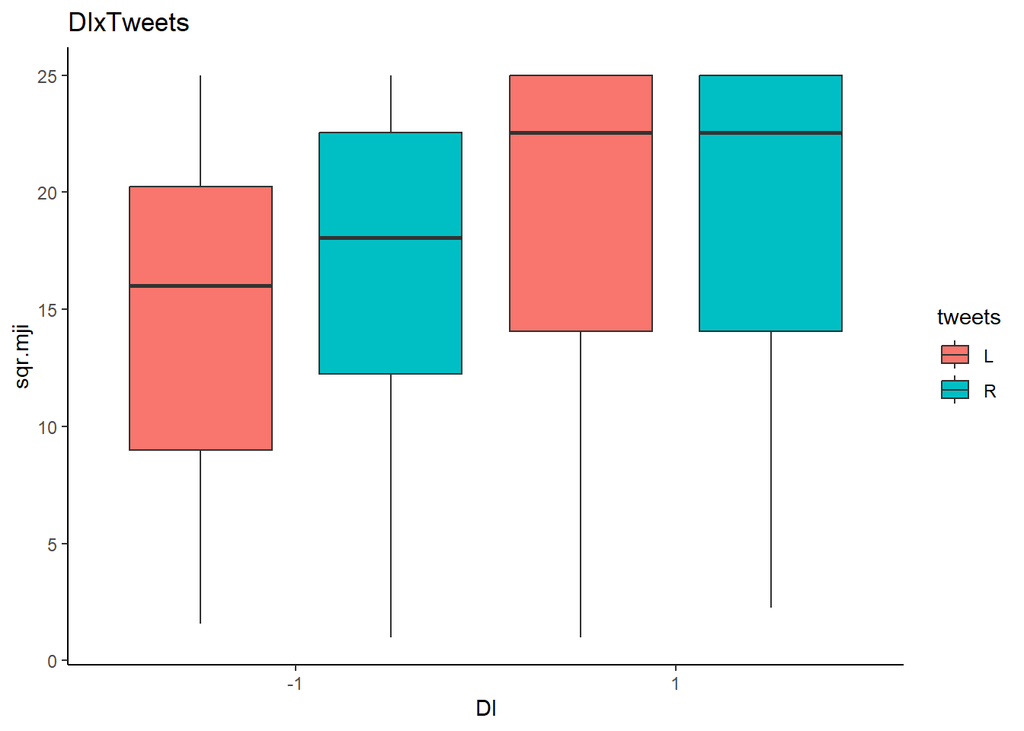

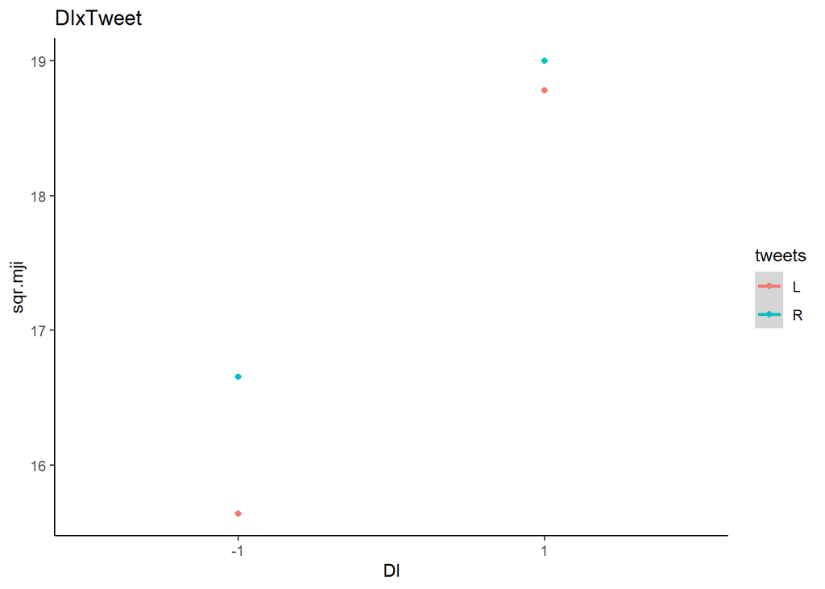

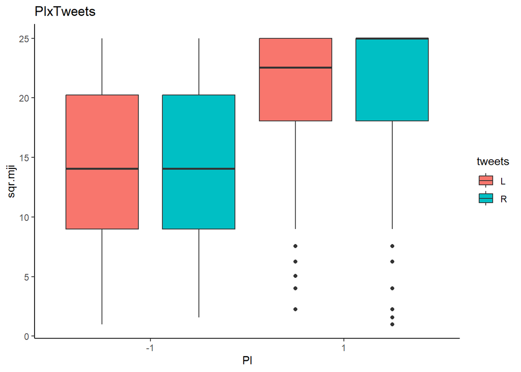

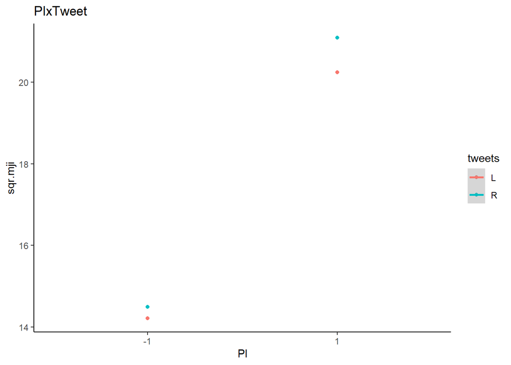

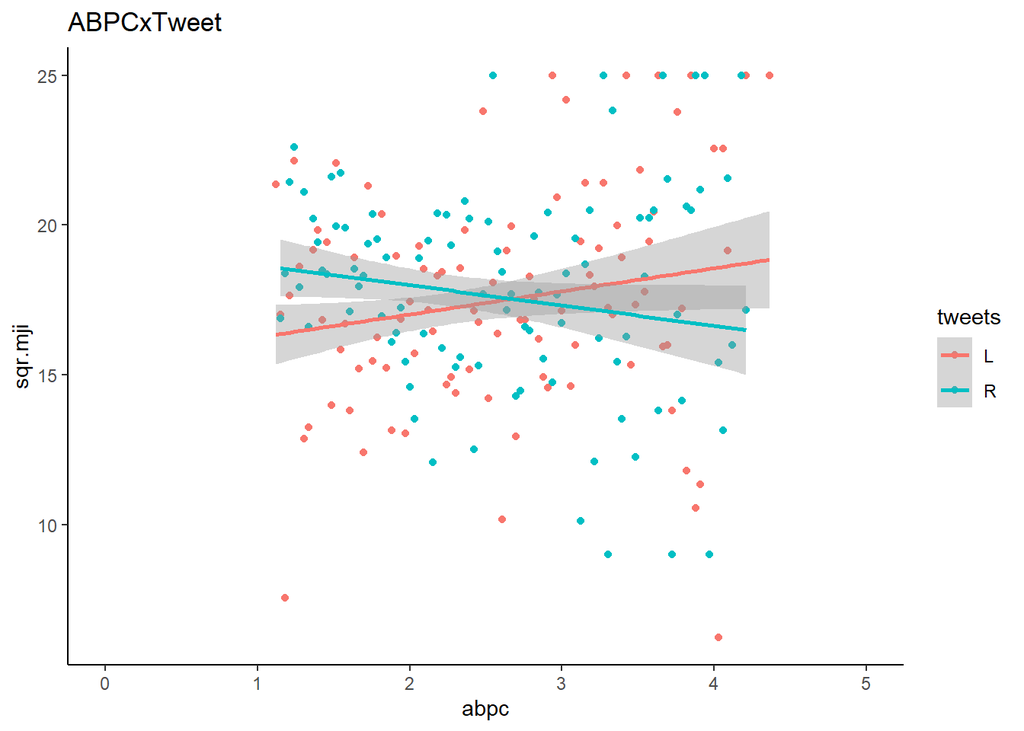

# Simple effects (split by intent conditions and ABPC)

- BA cases =320
- PIO cases =324
- DIO cases =322
- BP cases =320

### BA

```
##
## Call:
## lm(formula = sqr.mji ~ tweets + abpc + tweets * abpc, data = subset(dat,
##     Cond_int == "BA"))
##
## Residuals:
##      Min       1Q   Median       3Q      Max
## -13.1098  -4.9962   0.2446   4.3300  12.4413
##
## Coefficients:
##              Estimate Std. Error t value Pr(>|t|)
## (Intercept)    9.3234     1.6408   5.682 3.02e-08 ***
## tweetsR        9.7211     2.3001   4.226 3.11e-05 ***
## abpc           1.9412     0.6635   2.926 0.003687 **
## tweetsR:abpc  -3.7225     0.9548  -3.899 0.000118 ***
## ---
## Signif. codes:  0 '***' 0.001 '**' 0.01 '*' 0.05 '.' 0.1 ' ' 1
##
## Residual standard error: 6.242 on 316 degrees of freedom
## Multiple R-squared:  0.05408,    Adjusted R-squared:  0.0451
## F-statistic: 6.022 on 3 and 316 DF,  p-value: 0.0005327
```

### Regression Coefficients

```
##
## Call:
## lm(formula = sqr.mji ~ tweets + abpc + tweets * abpc, data = subset(dat,
##     Cond_int == "BA"))
##
## Standardized Coefficients::
##  (Intercept)      tweetsR         abpc tweetsR:abpc
##           NA    0.7614165    0.2232578   -0.7172286
```

### PIO

```
##
## Call:
## lm(formula = sqr.mji ~ tweets + abpc + tweets * abpc, data = subset(dat,
##     Cond_int == "PIO"))
##
## Residuals:
##     Min      1Q  Median      3Q     Max
## -15.955  -5.013   1.115   5.558   9.097
##
## Coefficients:
##              Estimate Std. Error t value Pr(>|t|)
## (Intercept)   14.4935     1.6254   8.917  < 2e-16 ***
## tweetsR        7.1062     2.3154   3.069  0.00233 **
## abpc           1.2211     0.6846   1.784  0.07540 .
## tweetsR:abpc  -2.6672     0.9690  -2.752  0.00625 **
## ---
## Signif. codes:  0 '***' 0.001 '**' 0.01 '*' 0.05 '.' 0.1 ' ' 1
##
## Residual standard error: 6.366 on 320 degrees of freedom
## Multiple R-squared:  0.02962,    Adjusted R-squared:  0.02053
## F-statistic: 3.256 on 3 and 320 DF,  p-value: 0.02191
```

### Regression Coefficients

```
##
## Call:
## lm(formula = sqr.mji ~ tweets + abpc + tweets * abpc, data = subset(dat,
##     Cond_int == "PIO"))
##
## Standardized Coefficients::
##  (Intercept)      tweetsR         abpc tweetsR:abpc
##           NA    0.5530271    0.1388111   -0.5209731
```

### DIO

```
##
## Call:
## lm(formula = sqr.mji ~ tweets + abpc + tweets * abpc, data = subset(dat,
##     Cond_int == "DIO"))
##
## Residuals:
##      Min       1Q   Median       3Q      Max
## -12.9682  -5.3251  -0.2275   4.8166  12.0128
##
## Coefficients:
##              Estimate Std. Error t value Pr(>|t|)
## (Intercept)   11.5590     1.6393   7.051 1.11e-11 ***
## tweetsR        4.7325     2.3602   2.005   0.0458 *
## abpc           1.3033     0.6913   1.885   0.0603 .
## tweetsR:abpc  -2.3938     1.0079  -2.375   0.0181 *
## ---
## Signif. codes:  0 '***' 0.001 '**' 0.01 '*' 0.05 '.' 0.1 ' ' 1
##
## Residual standard error: 6.25 on 318 degrees of freedom
## Multiple R-squared:  0.02029,    Adjusted R-squared:  0.01105
## F-statistic: 2.195 on 3 and 318 DF,  p-value: 0.08853
```

### Regression Coefficients

```
##
## Call:
## lm(formula = sqr.mji ~ tweets + abpc + tweets * abpc, data = subset(dat,
##     Cond_int == "DIO"))
##
## Standardized Coefficients::
##  (Intercept)      tweetsR         abpc tweetsR:abpc
##           NA    0.3766339    0.1439181   -0.4583570
```

### BP

```
##
## Call:
## lm(formula = sqr.mji ~ tweets + abpc + tweets * abpc, data = subset(dat,
##     Cond_int == "BP"))
##
## Residuals:
##      Min       1Q   Median       3Q      Max
## -11.5426  -0.8452   1.2114   1.2915   1.9984
##
## Coefficients:
##              Estimate Std. Error t value Pr(>|t|)
## (Intercept)   22.4922     0.6444  34.905   <2e-16 ***
## tweetsR        1.3724     0.9206   1.491    0.137
## abpc           0.4543     0.2839   1.600    0.110
## tweetsR:abpc  -0.4984     0.3896  -1.279    0.202
## ---
## Signif. codes:  0 '***' 0.001 '**' 0.01 '*' 0.05 '.' 0.1 ' ' 1
##
## Residual standard error: 2.58 on 316 degrees of freedom
## Multiple R-squared:  0.01132,    Adjusted R-squared:  0.001937
## F-statistic: 1.206 on 3 and 316 DF,  p-value: 0.3075
```

### Regression Coefficients

```
##
## Call:
## lm(formula = sqr.mji ~ tweets + abpc + tweets * abpc, data = subset(dat,
##     Cond_int == "BP"))
##
## Standardized Coefficients::
##  (Intercept)      tweetsR         abpc tweetsR:abpc
##           NA    0.2659972    0.1318724   -0.2495950
```

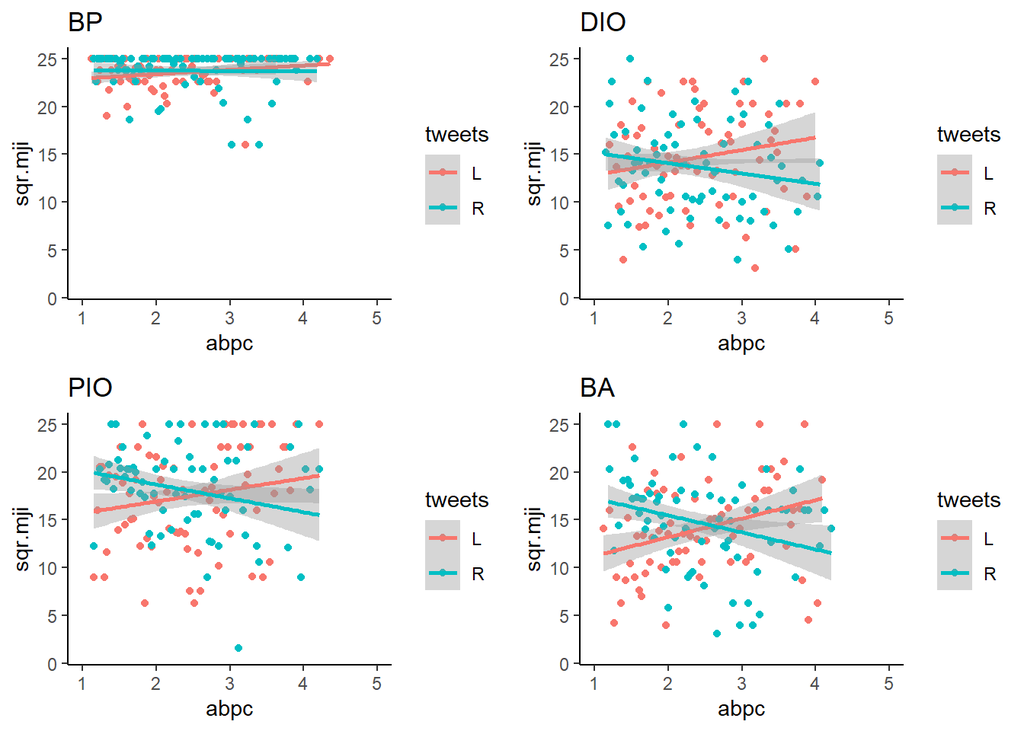

## Left of midpoint (ABPC < 2)

- Full cases =625
- BA cases =157
- PIO cases =153
- DIO cases =157
- BP cases =158

### Full model

```
##
## Call:
## lm(formula = sqr.mji ~ PI * DI * tweets, data = subset(dat, abpc <
##     med.abpc))
##
## Residuals:
##     Min      1Q  Median      3Q     Max
## -15.150  -4.128   1.100   3.412  12.698
##
## Coefficients:
##                 Estimate Std. Error t value Pr(>|t|)
## (Intercept)      12.3016     0.6741  18.250  < 2e-16 ***
## PI1               4.6762     0.9226   5.068 5.31e-07 ***
## DI1               1.0822     0.9254   1.169   0.2427
## tweetsR           3.9505     0.9003   4.388 1.35e-05 ***
## PI1:DI1           5.2339     1.2753   4.104 4.61e-05 ***
## PI1:tweetsR      -1.7780     1.2772  -1.392   0.1644
## DI1:tweetsR      -2.6436     1.2686  -2.084   0.0376 *
## PI1:DI1:tweetsR   0.7305     1.7963   0.407   0.6844
## ---
## Signif. codes:  0 '***' 0.001 '**' 0.01 '*' 0.05 '.' 0.1 ' ' 1
##
## Residual standard error: 5.599 on 617 degrees of freedom
## Multiple R-squared:  0.334,  Adjusted R-squared:  0.3264
## F-statistic:  44.2 on 7 and 617 DF,  p-value: < 2.2e-16
```

### Regression Coefficients

```
##
## Call:
## lm(formula = sqr.mji ~ PI * DI * tweets, data = subset(dat, abpc <
##     med.abpc))
##
## Standardized Coefficients::
##     (Intercept)             PI1             DI1         tweetsR         PI1:DI1
##              NA      0.34297861      0.07937146      0.28974471      0.33368522
##     PI1:tweetsR     DI1:tweetsR PI1:DI1:tweetsR
##     -0.11087960     -0.16674312      0.03461958
```

### BA

```
##
## Call:
## lm(formula = sqr.mji ~ tweets, data = subset(dat, Cond_int ==
##     "BA" & abpc < med.abpc))
##
## Residuals:
##      Min       1Q   Median       3Q      Max
## -12.2521  -5.6896  -0.0516   3.9979  12.6984
##
## Coefficients:
##             Estimate Std. Error t value Pr(>|t|)
## (Intercept)  12.3016     0.7637  16.108  < 2e-16 ***
## tweetsR       3.9505     1.0201   3.873 0.000158 ***
## ---
## Signif. codes:  0 '***' 0.001 '**' 0.01 '*' 0.05 '.' 0.1 ' ' 1
##
## Residual standard error: 6.344 on 155 degrees of freedom
## Multiple R-squared:  0.08823,    Adjusted R-squared:  0.08234
## F-statistic:    15 on 1 and 155 DF,  p-value: 0.0001583
```

### Regression Coefficients

```
##
## Call:
## lm(formula = sqr.mji ~ tweets, data = subset(dat, Cond_int ==
##     "BA" & abpc < med.abpc))
##
## Standardized Coefficients::
## (Intercept)     tweetsR
##          NA   0.2970299
```

### PIO

```
##
## Call:
## lm(formula = sqr.mji ~ tweets, data = subset(dat, Cond_int ==
##     "PIO" & abpc < med.abpc))
##
## Residuals:
##     Min      1Q  Median      3Q     Max
## -15.150  -4.728   1.100   5.585   8.022
##
## Coefficients:
##             Estimate Std. Error t value Pr(>|t|)
## (Intercept)  16.9778     0.6947  24.438   <2e-16 ***
## tweetsR       2.1725     0.9990   2.175   0.0312 *
## ---
## Signif. codes:  0 '***' 0.001 '**' 0.01 '*' 0.05 '.' 0.1 ' ' 1
##
## Residual standard error: 6.175 on 151 degrees of freedom
## Multiple R-squared:  0.03037,    Adjusted R-squared:  0.02395
## F-statistic:  4.73 on 1 and 151 DF,  p-value: 0.0312
```

### Regression Coefficients

```
##
## Call:
## lm(formula = sqr.mji ~ tweets, data = subset(dat, Cond_int ==
##     "PIO" & abpc < med.abpc))
##
## Standardized Coefficients::
## (Intercept)     tweetsR
##          NA   0.1742717
```

### DIO

```
##
## Call:
## lm(formula = sqr.mji ~ tweets, data = subset(dat, Cond_int ==
##     "DIO" & abpc < med.abpc))
##
## Residuals:
##      Min       1Q   Median       3Q      Max
## -12.3838  -5.6907  -0.6282   5.5593  11.6162
##
## Coefficients:
##             Estimate Std. Error t value Pr(>|t|)
## (Intercept)  13.3838     0.7137  18.752   <2e-16 ***
## tweetsR       1.3069     1.0062   1.299    0.196
## ---
## Signif. codes:  0 '***' 0.001 '**' 0.01 '*' 0.05 '.' 0.1 ' ' 1
##
## Residual standard error: 6.304 on 155 degrees of freedom
## Multiple R-squared:  0.01077,    Adjusted R-squared:  0.004384
## F-statistic: 1.687 on 1 and 155 DF,  p-value: 0.1959
```

### Regression Coefficients

```
##
## Call:
## lm(formula = sqr.mji ~ tweets, data = subset(dat, Cond_int ==
##     "DIO" & abpc < med.abpc))
##
## Standardized Coefficients::
## (Intercept)     tweetsR
##          NA   0.1037613
```

### BP

```
##
## Call:
## lm(formula = sqr.mji ~ tweets, data = subset(dat, Cond_int ==
##     "BP" & abpc < med.abpc))
##
## Residuals:
##      Min       1Q   Median       3Q      Max
## -11.3032  -0.7314   1.4468   1.7061   1.7061
##
## Coefficients:
##             Estimate Std. Error t value Pr(>|t|)
## (Intercept)  23.2939     0.3013  77.314   <2e-16 ***
## tweetsR       0.2593     0.4402   0.589    0.557
## ---
## Signif. codes:  0 '***' 0.001 '**' 0.01 '*' 0.05 '.' 0.1 ' ' 1
##
## Residual standard error: 2.761 on 156 degrees of freedom
## Multiple R-squared:  0.002219,   Adjusted R-squared:  -0.004177
## F-statistic: 0.3469 on 1 and 156 DF,  p-value: 0.5567
```

### Regression Coefficients

```
##
## Call:
## lm(formula = sqr.mji ~ tweets, data = subset(dat, Cond_int ==
##     "BP" & abpc < med.abpc))
##
## Standardized Coefficients::
## (Intercept)     tweetsR
##          NA  0.04710648
```

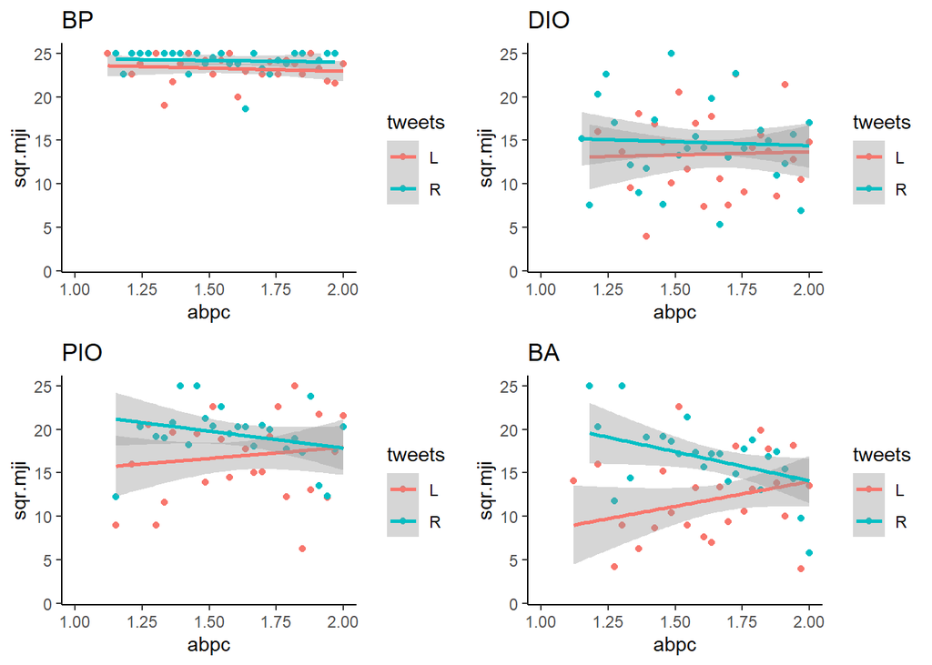

## RIGHT of midpoint (ABPC > 2)

- Full cases =661
- BA cases =163
- PIO cases =171
- DIO cases =165
- BP cases =162

### Full model

```
##
## Call:
## lm(formula = sqr.mji ~ PI * DI * tweets, data = subset(dat, abpc >=
##     med.abpc))
##
## Residuals:
##     Min      1Q  Median      3Q     Max
## -16.534  -3.445   1.071   3.146  12.146
##
## Coefficients:
##                 Estimate Std. Error t value Pr(>|t|)
## (Intercept)      15.1964     0.6126  24.805  < 2e-16 ***
## PI1               2.3115     0.8589   2.691   0.0073 **
## DI1               0.2857     0.8496   0.336   0.7367
## tweetsR          -1.3339     0.8772  -1.521   0.1288
## PI1:DI1           5.8841     1.2388   4.750  2.5e-06 ***
## PI1:tweetsR       1.3603     1.2276   1.108   0.2683
## DI1:tweetsR      -1.2946     1.2441  -1.041   0.2984
## PI1:DI1:tweetsR   1.5193     1.7546   0.866   0.3869
## ---
## Signif. codes:  0 '***' 0.001 '**' 0.01 '*' 0.05 '.' 0.1 ' ' 1
##
## Residual standard error: 5.615 on 653 degrees of freedom
## Multiple R-squared:  0.3253, Adjusted R-squared:  0.318
## F-statistic: 44.97 on 7 and 653 DF,  p-value: < 2.2e-16
```

### Regression Coefficients

```
##
## Call:
## lm(formula = sqr.mji ~ PI * DI * tweets, data = subset(dat, abpc >=
##     med.abpc))
##
## Standardized Coefficients::
##     (Intercept)             PI1             DI1         tweetsR         PI1:DI1
##              NA      0.17010567      0.02102490     -0.09816809      0.37252534
##     PI1:tweetsR     DI1:tweetsR PI1:DI1:tweetsR
##      0.08849475     -0.08246988      0.07740338
```

### BA

```
##
## Call:
## lm(formula = sqr.mji ~ tweets, data = subset(dat, Cond_int ==
##     "BA" & abpc >= med.abpc))
##
## Residuals:
##     Min      1Q  Median      3Q     Max
## -12.159  -4.634   0.341   4.341  11.278
##
## Coefficients:
##             Estimate Std. Error t value Pr(>|t|)
## (Intercept)  15.1964     0.6708  22.655   <2e-16 ***
## tweetsR      -1.4749     0.9635  -1.531    0.128
## ---
## Signif. codes:  0 '***' 0.001 '**' 0.01 '*' 0.05 '.' 0.1 ' ' 1
##
## Residual standard error: 6.148 on 161 degrees of freedom
## Multiple R-squared:  0.01435,    Adjusted R-squared:  0.008223
## F-statistic: 2.343 on 1 and 161 DF,  p-value: 0.1278
```

### Regression Coefficients

```
##
## Call:
## lm(formula = sqr.mji ~ tweets, data = subset(dat, Cond_int ==
##     "BA" & abpc >= med.abpc))
##
## Standardized Coefficients::
## (Intercept)     tweetsR
##          NA  -0.1197719
```

### PIO

```
##
## Call:
## lm(formula = sqr.mji ~ tweets, data = subset(dat, Cond_int ==
##     "PIO" & abpc >= med.abpc))
##
## Residuals:
##      Min       1Q   Median       3Q      Max
## -16.5342  -5.2711   0.5546   5.0546   7.4921
##
## Coefficients:
##             Estimate Std. Error t value Pr(>|t|)
## (Intercept) 17.50790    0.70979  24.666   <2e-16 ***
## tweetsR      0.02632    1.01272   0.026    0.979
## ---
## Signif. codes:  0 '***' 0.001 '**' 0.01 '*' 0.05 '.' 0.1 ' ' 1
##
## Residual standard error: 6.621 on 169 degrees of freedom
## Multiple R-squared:  3.998e-06,  Adjusted R-squared:  -0.005913
## F-statistic: 0.0006756 on 1 and 169 DF,  p-value: 0.9793
```

### Regression Coefficients

```
##
## Call:
## lm(formula = sqr.mji ~ tweets, data = subset(dat, Cond_int ==
##     "PIO" & abpc >= med.abpc))
##
## Standardized Coefficients::
## (Intercept)     tweetsR
##          NA 0.001999476
```

### DIO

```
##
## Call:
## lm(formula = sqr.mji ~ tweets, data = subset(dat, Cond_int ==
##     "DIO" & abpc >= med.abpc))
##
## Residuals:
##      Min       1Q   Median       3Q      Max
## -12.4196  -4.9196   0.5179   4.7679  11.9823
##
## Coefficients:
##             Estimate Std. Error t value Pr(>|t|)
## (Intercept)  15.4821     0.6463  23.955   <2e-16 ***
## tweetsR      -2.4644     0.9651  -2.554   0.0116 *
## ---
## Signif. codes:  0 '***' 0.001 '**' 0.01 '*' 0.05 '.' 0.1 ' ' 1
##
## Residual standard error: 6.165 on 163 degrees of freedom
## Multiple R-squared:  0.03847,    Adjusted R-squared:  0.03257
## F-statistic: 6.521 on 1 and 163 DF,  p-value: 0.01158
```

### Regression Coefficients

```
##
## Call:
## lm(formula = sqr.mji ~ tweets, data = subset(dat, Cond_int ==
##     "DIO" & abpc >= med.abpc))
##
## Standardized Coefficients::
## (Intercept)     tweetsR
##          NA   -0.196131
```

### BP

```
##
## Call:
## lm(formula = sqr.mji ~ tweets, data = subset(dat, Cond_int ==
##     "BP" & abpc >= med.abpc))
##
## Residuals:
##     Min      1Q  Median      3Q     Max
## -11.679  -1.115   1.071   1.322   1.322
##
## Coefficients:
##             Estimate Std. Error t value Pr(>|t|)
## (Intercept)  23.6777     0.2864   82.66   <2e-16 ***
## tweetsR       0.2510     0.3801    0.66     0.51
## ---
## Signif. codes:  0 '***' 0.001 '**' 0.01 '*' 0.05 '.' 0.1 ' ' 1
##
## Residual standard error: 2.397 on 160 degrees of freedom
## Multiple R-squared:  0.002718,   Adjusted R-squared:  -0.003515
## F-statistic: 0.436 on 1 and 160 DF,  p-value: 0.51
```

### Regression Coefficients

```
##
## Call:
## lm(formula = sqr.mji ~ tweets, data = subset(dat, Cond_int ==
##     "BP" & abpc >= med.abpc))
##
## Standardized Coefficients::
## (Intercept)     tweetsR
##          NA  0.05213235
```

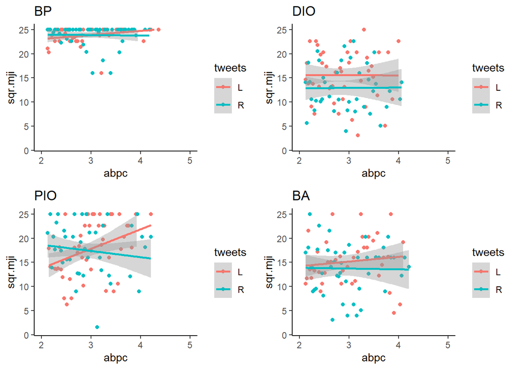

## Left of midpoint (ABPC < 2) w/ ABPC factor 1 (LI)

- Full cases =635
- BA cases =160
- PIO cases =158
- DIO cases =160
- BP cases =157

### Full model

```
##
## Call:
## lm(formula = sqr.mji ~ abpc * PI * DI * tweets, data = subset(dat,
##     abpc.mi < med.abpc.mi))
##
## Residuals:
##      Min       1Q   Median       3Q      Max
## -13.5422  -3.8546   0.7828   3.4981  12.6679
##
## Coefficients:
##                       Estimate Std. Error t value Pr(>|t|)
## (Intercept)            3.55435    3.72483   0.954 0.340338
## abpc                   5.26666    2.07440   2.539 0.011364 *
## PI1                    9.00193    5.05282   1.782 0.075310 .
## DI1                    4.97040    4.76563   1.043 0.297371
## tweetsR               22.24983    5.42454   4.102 4.65e-05 ***
## abpc:PI1              -2.51095    2.88494  -0.870 0.384437
## abpc:DI1              -2.25867    2.66141  -0.849 0.396390
## PI1:DI1                5.63283    6.79972   0.828 0.407768
## abpc:tweetsR         -10.79069    3.08032  -3.503 0.000493 ***
## PI1:tweetsR           -8.38962    7.27348  -1.153 0.249170
## DI1:tweetsR          -14.64189    7.08800  -2.066 0.039270 *
## abpc:PI1:DI1          -0.37367    3.92967  -0.095 0.924275
## abpc:PI1:tweetsR       3.72832    4.17715   0.893 0.372445
## abpc:DI1:tweetsR       6.97036    4.03827   1.726 0.084833 .
## PI1:DI1:tweetsR        1.85008    9.81267   0.189 0.850515
## abpc:PI1:DI1:tweetsR  -0.03802    5.66919  -0.007 0.994651
## ---
## Signif. codes:  0 '***' 0.001 '**' 0.01 '*' 0.05 '.' 0.1 ' ' 1
##
## Residual standard error: 5.513 on 619 degrees of freedom
## Multiple R-squared:  0.3564, Adjusted R-squared:  0.3408
## F-statistic: 22.85 on 15 and 619 DF,  p-value: < 2.2e-16
```

### Regression Coefficients

```
##
## Call:
## lm(formula = sqr.mji ~ abpc * PI * DI * tweets, data = subset(dat,
##     abpc.mi < med.abpc.mi))
##
## Standardized Coefficients::
##          (Intercept)                 abpc                  PI1
##                   NA           0.24504108           0.66344799
##                  DI1              tweetsR             abpc:PI1
##           0.36633214           1.63963063          -0.32085510
##             abpc:DI1              PI1:DI1         abpc:tweetsR
##          -0.29228773           0.35820463          -1.39782228
##          PI1:tweetsR          DI1:tweetsR         abpc:PI1:DI1
##          -0.52285132          -0.91034584          -0.04047623
##     abpc:PI1:tweetsR     abpc:DI1:tweetsR      PI1:DI1:tweetsR
##           0.40564286           0.75431088           0.08594116
## abpc:PI1:DI1:tweetsR
##          -0.00308210
```

### BA

```
##
## Call:
## lm(formula = sqr.mji ~ abpc * tweets, data = subset(dat, Cond_int ==
##     "BA" & abpc.mi < med.abpc.mi))
##
## Residuals:
##      Min       1Q   Median       3Q      Max
## -11.8231  -5.1429   0.6088   4.6163  12.6679
##
## Coefficients:
##              Estimate Std. Error t value Pr(>|t|)
## (Intercept)     3.554      4.279   0.831 0.407452
## abpc            5.267      2.383   2.210 0.028560 *
## tweetsR        22.250      6.232   3.570 0.000474 ***
## abpc:tweetsR  -10.791      3.539  -3.049 0.002695 **
## ---
## Signif. codes:  0 '***' 0.001 '**' 0.01 '*' 0.05 '.' 0.1 ' ' 1
##
## Residual standard error: 6.333 on 156 degrees of freedom
## Multiple R-squared:  0.1201, Adjusted R-squared:  0.1032
## F-statistic: 7.096 on 3 and 156 DF,  p-value: 0.0001682
```

### Regression Coefficients

```
##
## Call:
## lm(formula = sqr.mji ~ abpc * tweets, data = subset(dat, Cond_int ==
##     "BA" & abpc.mi < med.abpc.mi))
##
## Standardized Coefficients::
##  (Intercept)         abpc      tweetsR abpc:tweetsR
##           NA    0.2255883    1.6604932   -1.4134239
```

### PIO

```
##
## Call:
## lm(formula = sqr.mji ~ abpc * tweets, data = subset(dat, Cond_int ==
##     "PIO" & abpc.mi < med.abpc.mi))
##
## Residuals:
##     Min      1Q  Median      3Q     Max
## -13.542  -5.061   1.142   4.978   9.415
##
## Coefficients:
##              Estimate Std. Error t value Pr(>|t|)
## (Intercept)    12.556      3.769   3.332  0.00108 **
## abpc            2.756      2.213   1.245  0.21496
## tweetsR        13.860      5.349   2.591  0.01048 *
## abpc:tweetsR   -7.062      3.114  -2.268  0.02474 *
## ---
## Signif. codes:  0 '***' 0.001 '**' 0.01 '*' 0.05 '.' 0.1 ' ' 1
##
## Residual standard error: 6.085 on 154 degrees of freedom
## Multiple R-squared:  0.05696,    Adjusted R-squared:  0.03859
## F-statistic: 3.101 on 3 and 154 DF,  p-value: 0.02849
```

### Regression Coefficients

```
##
## Call:
## lm(formula = sqr.mji ~ abpc * tweets, data = subset(dat, Cond_int ==
##     "PIO" & abpc.mi < med.abpc.mi))
##
## Standardized Coefficients::
##  (Intercept)         abpc      tweetsR abpc:tweetsR
##           NA    0.1386259    1.1198877   -1.0039104
```

### DIO

```
##
## Call:
## lm(formula = sqr.mji ~ abpc * tweets, data = subset(dat, Cond_int ==
##     "DIO" & abpc.mi < med.abpc.mi))
##
## Residuals:
##      Min       1Q   Median       3Q      Max
## -13.0850  -5.1666  -0.6708   5.2957  12.1912
##
## Coefficients:
##              Estimate Std. Error t value Pr(>|t|)
## (Intercept)     8.525      3.351   2.544   0.0119 *
## abpc            3.008      1.880   1.600   0.1116
## tweetsR         7.608      5.144   1.479   0.1411
## abpc:tweetsR   -3.820      2.944  -1.298   0.1963
## ---
## Signif. codes:  0 '***' 0.001 '**' 0.01 '*' 0.05 '.' 0.1 ' ' 1
##
## Residual standard error: 6.215 on 156 degrees of freedom
## Multiple R-squared:  0.02306,    Adjusted R-squared:  0.004274
## F-statistic: 1.227 on 3 and 156 DF,  p-value: 0.3017
```

### Regression Coefficients

```
##
## Call:
## lm(formula = sqr.mji ~ abpc * tweets, data = subset(dat, Cond_int ==
##     "DIO" & abpc.mi < med.abpc.mi))
##
## Standardized Coefficients::
##  (Intercept)         abpc      tweetsR abpc:tweetsR
##           NA    0.1650345    0.6119125   -0.5370445
```

### BP

```
##
## Call:
## lm(formula = sqr.mji ~ abpc * tweets, data = subset(dat, Cond_int ==
##     "BP" & abpc.mi < med.abpc.mi))
##
## Residuals:
##      Min       1Q   Median       3Q      Max
## -11.9670  -0.7989   0.7832   1.6050   1.7022
##
## Coefficients:
##              Estimate Std. Error t value Pr(>|t|)
## (Intercept)   23.1595     1.4522  15.948   <2e-16 ***
## abpc           0.1234     0.8781   0.140    0.888
## tweetsR        1.0684     2.0026   0.534    0.594
## abpc:tweetsR  -0.1300     1.1827  -0.110    0.913
## ---
## Signif. codes:  0 '***' 0.001 '**' 0.01 '*' 0.05 '.' 0.1 ' ' 1
##
## Residual standard error: 2.324 on 153 degrees of freedom
## Multiple R-squared:  0.03347,    Adjusted R-squared:  0.01452
## F-statistic: 1.766 on 3 and 153 DF,  p-value: 0.156
```

### Regression Coefficients

```
##
## Call:
## lm(formula = sqr.mji ~ abpc * tweets, data = subset(dat, Cond_int ==
##     "BP" & abpc.mi < med.abpc.mi))
##
## Standardized Coefficients::
##  (Intercept)         abpc      tweetsR abpc:tweetsR
##           NA   0.01679017   0.22790696  -0.04907224
```

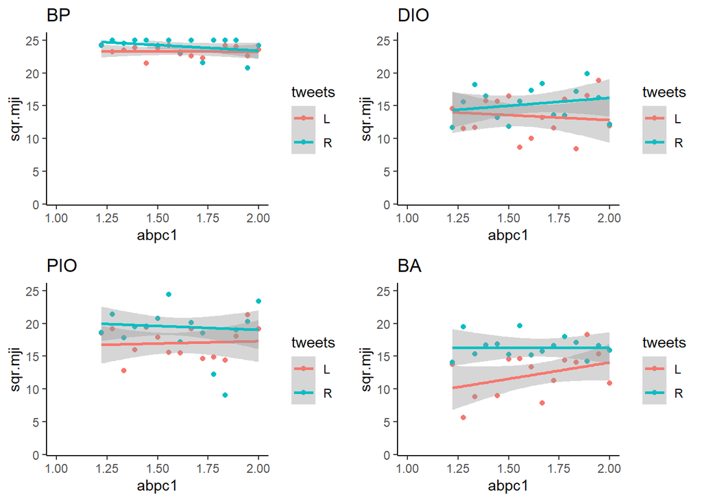

## RIGHT of midpoint (ABPC > 2) w/ ABPC factor 1 (LI)

### Full model

```
##
## Call:
## lm(formula = sqr.mji ~ abpc * PI * DI * tweets, data = subset(dat,
##     abpc.mi >= med.abpc.mi))
##
## Residuals:
##      Min       1Q   Median       3Q      Max
## -16.2418  -3.6628   0.8666   3.3671  12.2479
##
## Coefficients:
##                      Estimate Std. Error t value Pr(>|t|)
## (Intercept)           10.4329     2.8164   3.704  0.00023 ***
## abpc                   1.5207     0.9557   1.591  0.11206
## PI1                   -1.9818     4.3211  -0.459  0.64665
## DI1                    3.7683     4.2419   0.888  0.37469
## tweetsR                1.7581     4.3011   0.409  0.68286
## abpc:PI1               1.6283     1.4886   1.094  0.27443
## abpc:DI1              -1.1466     1.4715  -0.779  0.43612
## PI1:DI1                8.2440     6.3344   1.301  0.19358
## abpc:tweetsR          -0.9659     1.4777  -0.654  0.51356
## PI1:tweetsR            9.6249     6.2595   1.538  0.12463
## DI1:tweetsR           -2.1710     6.2090  -0.350  0.72671
## abpc:PI1:DI1          -0.8827     2.2034  -0.401  0.68884
## abpc:PI1:tweetsR      -2.9901     2.1601  -1.384  0.16677
## abpc:DI1:tweetsR       0.2498     2.1754   0.115  0.90860
## PI1:DI1:tweetsR       -8.9417     8.8594  -1.009  0.31322
## abpc:PI1:DI1:tweetsR   3.5374     3.0895   1.145  0.25264
## ---
## Signif. codes:  0 '***' 0.001 '**' 0.01 '*' 0.05 '.' 0.1 ' ' 1
##
## Residual standard error: 5.647 on 635 degrees of freedom
## Multiple R-squared:  0.3316, Adjusted R-squared:  0.3158
## F-statistic:    21 on 15 and 635 DF,  p-value: < 2.2e-16
```

### Regression Coefficients

```
##
## Call:
## lm(formula = sqr.mji ~ abpc * PI * DI * tweets, data = subset(dat,
##     abpc.mi >= med.abpc.mi))
##
## Standardized Coefficients::
##          (Intercept)                 abpc                  PI1
##                   NA           0.12947480          -0.14524879
##                  DI1              tweetsR             abpc:PI1
##           0.27619394           0.12883507           0.35092127
##             abpc:DI1              PI1:DI1         abpc:tweetsR
##          -0.24377152           0.52355421          -0.20708968
##          PI1:tweetsR          DI1:tweetsR         abpc:PI1:DI1
##           0.62664574          -0.14005718          -0.16251561
##     abpc:PI1:tweetsR     abpc:DI1:tweetsR      PI1:DI1:tweetsR
##          -0.56786551           0.04610321          -0.46274189
## abpc:PI1:DI1:tweetsR
##           0.53070719
```

### BA

```
##
## Call:
## lm(formula = sqr.mji ~ abpc * tweets, data = subset(dat, Cond_int ==
##     "BA" & abpc.mi >= med.abpc.mi))
##
## Residuals:
##     Min      1Q  Median      3Q     Max
## -12.378  -4.227   0.477   4.395  11.709
##
## Coefficients:
##              Estimate Std. Error t value Pr(>|t|)
## (Intercept)    10.433      3.025   3.449 0.000723 ***
## abpc            1.521      1.026   1.482 0.140457
## tweetsR         1.872      4.620   0.405 0.685800
## abpc:tweetsR   -1.056      1.588  -0.665 0.506894
## ---
## Signif. codes:  0 '***' 0.001 '**' 0.01 '*' 0.05 '.' 0.1 ' ' 1
##
## Residual standard error: 6.065 on 156 degrees of freedom
## Multiple R-squared:  0.02417,    Adjusted R-squared:  0.005406
## F-statistic: 1.288 on 3 and 156 DF,  p-value: 0.2805
```

### Regression Coefficients

```
##
## Call:
## lm(formula = sqr.mji ~ abpc * tweets, data = subset(dat, Cond_int ==
##     "BA" & abpc.mi >= med.abpc.mi))
##
## Standardized Coefficients::
##  (Intercept)         abpc      tweetsR abpc:tweetsR
##           NA    0.1536999    0.1544261   -0.2557251
```

### PIO

```
##
## Call:
## lm(formula = sqr.mji ~ abpc * tweets, data = subset(dat, Cond_int ==
##     "PIO" & abpc.mi >= med.abpc.mi))
##
## Residuals:
##     Min      1Q  Median      3Q     Max
## -16.242  -5.090   1.250   5.215  10.633
##
## Coefficients:
##              Estimate Std. Error t value Pr(>|t|)
## (Intercept)     8.451      3.821   2.212   0.0284 *
## abpc            3.149      1.330   2.367   0.0191 *
## tweetsR        11.383      5.302   2.147   0.0333 *
## abpc:tweetsR   -3.956      1.837  -2.154   0.0327 *
## ---
## Signif. codes:  0 '***' 0.001 '**' 0.01 '*' 0.05 '.' 0.1 ' ' 1
##
## Residual standard error: 6.583 on 162 degrees of freedom
## Multiple R-squared:  0.03599,    Adjusted R-squared:  0.01814
## F-statistic: 2.016 on 3 and 162 DF,  p-value: 0.1138
```

### Regression Coefficients

```
##
## Call:
## lm(formula = sqr.mji ~ abpc * tweets, data = subset(dat, Cond_int ==
##     "PIO" & abpc.mi >= med.abpc.mi))
##
## Standardized Coefficients::
##  (Intercept)         abpc      tweetsR abpc:tweetsR
##           NA    0.2648676    0.8589986   -0.8826747
```

### DIO

```
##
## Call:
## lm(formula = sqr.mji ~ abpc * tweets, data = subset(dat, Cond_int ==
##     "DIO" & abpc.mi >= med.abpc.mi))
##
## Residuals:
##     Min      1Q  Median      3Q     Max
## -12.329  -5.392   0.058   4.925  12.041
##
## Coefficients:
##              Estimate Std. Error t value Pr(>|t|)
## (Intercept)   14.2012     3.5488   4.002 9.64e-05 ***
## abpc           0.3741     1.2517   0.299    0.765
## tweetsR       -0.6719     5.0078  -0.134    0.893
## abpc:tweetsR  -0.5624     1.7842  -0.315    0.753
## ---
## Signif. codes:  0 '***' 0.001 '**' 0.01 '*' 0.05 '.' 0.1 ' ' 1
##
## Residual standard error: 6.318 on 158 degrees of freedom
## Multiple R-squared:  0.0314, Adjusted R-squared:  0.01301
## F-statistic: 1.707 on 3 and 158 DF,  p-value: 0.1677
```

### Regression Coefficients

```
##
## Call:
## lm(formula = sqr.mji ~ abpc * tweets, data = subset(dat, Cond_int ==
##     "DIO" & abpc.mi >= med.abpc.mi))
##
## Standardized Coefficients::
##  (Intercept)         abpc      tweetsR abpc:tweetsR
##           NA   0.03288648  -0.05292993  -0.12540756
```

### BP

```
##
## Call:
## lm(formula = sqr.mji ~ abpc * tweets, data = subset(dat, Cond_int ==
##     "BP" & abpc.mi >= med.abpc.mi))
##
## Residuals:
##      Min       1Q   Median       3Q      Max
## -11.5669  -0.7848   0.9741   1.7569   2.5374
##
## Coefficients:
##              Estimate Std. Error t value Pr(>|t|)
## (Intercept)   20.4634     1.6462  12.430   <2e-16 ***
## abpc           1.1196     0.5745   1.949   0.0531 .
## tweetsR        0.2704     2.1404   0.126   0.8996
## abpc:tweetsR  -0.1688     0.7446  -0.227   0.8210
## ---
## Signif. codes:  0 '***' 0.001 '**' 0.01 '*' 0.05 '.' 0.1 ' ' 1
##
## Residual standard error: 2.754 on 159 degrees of freedom
## Multiple R-squared:  0.04794,    Adjusted R-squared:  0.02997
## F-statistic: 2.669 on 3 and 159 DF,  p-value: 0.04955
```

### Regression Coefficients

```
##
## Call:
## lm(formula = sqr.mji ~ abpc * tweets, data = subset(dat, Cond_int ==
##     "BP" & abpc.mi >= med.abpc.mi))
##
## Standardized Coefficients::
##  (Intercept)         abpc      tweetsR abpc:tweetsR
##           NA   0.23712121   0.04781614  -0.08875349
```

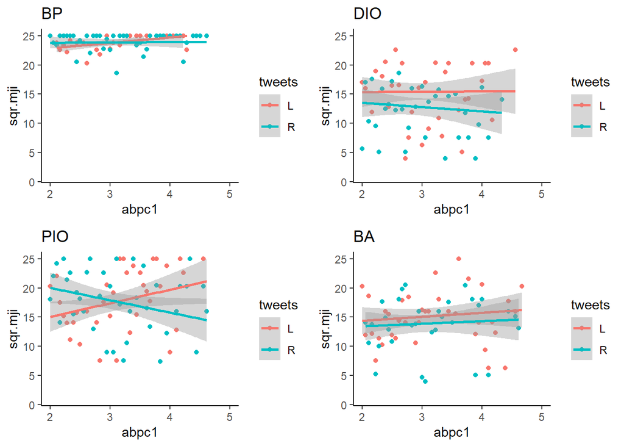

## Left of midpoint (ABPC < 2) w/ ABPC factor 2 (RT)

- Full cases =593
- BA cases =148
- PIO cases =143
- DIO cases =148
- BP cases =154

### Full model

```
##
## Call:
## lm(formula = sqr.mji ~ abpc * PI * DI * tweets, data = subset(dat,
##     abpc.rt < med.abpc.rt))
##
## Residuals:
##     Min      1Q  Median      3Q     Max
## -13.697  -3.713   0.953   3.336  12.945
##
## Coefficients:
##                      Estimate Std. Error t value Pr(>|t|)
## (Intercept)            4.8299     2.9800   1.621 0.105614
## abpc                   4.3349     1.5921   2.723 0.006668 **
## PI1                   16.2535     4.0395   4.024 6.49e-05 ***
## DI1                    2.4016     4.1492   0.579 0.562944
## tweetsR               14.9950     3.8999   3.845 0.000134 ***
## abpc:PI1              -7.0936     2.2472  -3.157 0.001680 **
## abpc:DI1              -0.5511     2.2586  -0.244 0.807303
## PI1:DI1               -0.2417     5.5942  -0.043 0.965551
## abpc:tweetsR          -6.0812     2.0852  -2.916 0.003679 **
## PI1:tweetsR          -16.0654     5.3544  -3.000 0.002813 **
## DI1:tweetsR           -3.3624     5.4569  -0.616 0.538021
## abpc:PI1:DI1           3.3714     3.1301   1.077 0.281893
## abpc:PI1:tweetsR       8.7987     2.9338   2.999 0.002825 **
## abpc:DI1:tweetsR      -0.2219     2.9576  -0.075 0.940212
## PI1:DI1:tweetsR        6.1125     7.5329   0.811 0.417448
## abpc:PI1:DI1:tweetsR  -3.2073     4.1395  -0.775 0.438775
## ---
## Signif. codes:  0 '***' 0.001 '**' 0.01 '*' 0.05 '.' 0.1 ' ' 1
##
## Residual standard error: 5.442 on 577 degrees of freedom
## Multiple R-squared:  0.3667, Adjusted R-squared:  0.3502
## F-statistic: 22.27 on 15 and 577 DF,  p-value: < 2.2e-16
```

### Regression Coefficients

```
##
## Call:
## lm(formula = sqr.mji ~ abpc * PI * DI * tweets, data = subset(dat,
##     abpc.rt < med.abpc.rt))
##
## Standardized Coefficients::
##          (Intercept)                 abpc                  PI1
##                   NA           0.28301220           1.20477929
##                  DI1              tweetsR             abpc:PI1
##           0.17798560           1.11065959          -0.97565833
##             abpc:DI1              PI1:DI1         abpc:tweetsR
##          -0.07632819          -0.01571211          -0.86574018
##          PI1:tweetsR          DI1:tweetsR         abpc:PI1:DI1
##          -1.02837872          -0.21523343           0.40011131
##     abpc:PI1:tweetsR     abpc:DI1:tweetsR      PI1:DI1:tweetsR
##           1.06275553          -0.02669382           0.29418526
## abpc:PI1:DI1:tweetsR
##          -0.29098976
```

### BA

```
##
## Call:
## lm(formula = sqr.mji ~ abpc * tweets, data = subset(dat, Cond_int ==
##     "BA" & abpc.rt < med.abpc.rt))
##
## Residuals:
##      Min       1Q   Median       3Q      Max
## -11.6404  -4.7704   0.2091   4.3475  12.9452
##
## Coefficients:
##              Estimate Std. Error t value Pr(>|t|)
## (Intercept)     4.830      3.308   1.460 0.146409
## abpc            4.335      1.767   2.453 0.015357 *
## tweetsR        14.995      4.329   3.464 0.000701 ***
## abpc:tweetsR   -6.081      2.314  -2.627 0.009535 **
## ---
## Signif. codes:  0 '***' 0.001 '**' 0.01 '*' 0.05 '.' 0.1 ' ' 1
##
## Residual standard error: 6.04 on 144 degrees of freedom
## Multiple R-squared:  0.1361, Adjusted R-squared:  0.1181
## F-statistic:  7.56 on 3 and 144 DF,  p-value: 9.879e-05
```

### Regression Coefficients

```
##
## Call:
## lm(formula = sqr.mji ~ abpc * tweets, data = subset(dat, Cond_int ==
##     "BA" & abpc.rt < med.abpc.rt))
##
## Standardized Coefficients::
##  (Intercept)         abpc      tweetsR abpc:tweetsR
##           NA    0.2942307    1.1566078   -0.9082526
```

### PIO

```
##
## Call:
## lm(formula = sqr.mji ~ abpc * tweets, data = subset(dat, Cond_int ==
##     "PIO" & abpc.rt < med.abpc.rt))
##
## Residuals:
##      Min       1Q   Median       3Q      Max
## -13.6970  -4.4478   0.3316   5.0499  10.2698
##
## Coefficients:
##              Estimate Std. Error t value Pr(>|t|)
## (Intercept)    21.083      3.066   6.877  1.9e-10 ***
## abpc           -2.759      1.783  -1.547    0.124
## tweetsR        -1.070      4.124  -0.260    0.796
## abpc:tweetsR    2.718      2.320   1.171    0.243
## ---
## Signif. codes:  0 '***' 0.001 '**' 0.01 '*' 0.05 '.' 0.1 ' ' 1
##
## Residual standard error: 6.118 on 139 degrees of freedom
## Multiple R-squared:  0.09006,    Adjusted R-squared:  0.07042
## F-statistic: 4.586 on 3 and 139 DF,  p-value: 0.004293
```

### Regression Coefficients

```
##
## Call:
## lm(formula = sqr.mji ~ abpc * tweets, data = subset(dat, Cond_int ==
##     "PIO" & abpc.rt < med.abpc.rt))
##
## Standardized Coefficients::
##  (Intercept)         abpc      tweetsR abpc:tweetsR
##           NA  -0.19767303  -0.08446952   0.41295046
```

### DIO

```
##
## Call:
## lm(formula = sqr.mji ~ abpc * tweets, data = subset(dat, Cond_int ==
##     "DIO" & abpc.rt < med.abpc.rt))
##
## Residuals:
##     Min      1Q  Median      3Q     Max
## -13.226  -5.623  -0.315   5.054  12.380
##
## Coefficients:
##              Estimate Std. Error t value Pr(>|t|)
## (Intercept)     7.231      3.323   2.176  0.03119 *
## abpc            3.784      1.844   2.052  0.04199 *
## tweetsR        11.633      4.393   2.648  0.00901 **
## abpc:tweetsR   -6.303      2.414  -2.611  0.00999 **
## ---
## Signif. codes:  0 '***' 0.001 '**' 0.01 '*' 0.05 '.' 0.1 ' ' 1
##
## Residual standard error: 6.264 on 144 degrees of freedom
## Multiple R-squared:  0.04665,    Adjusted R-squared:  0.02679
## F-statistic: 2.349 on 3 and 144 DF,  p-value: 0.07505
```

### Regression Coefficients

```
##
## Call:
## lm(formula = sqr.mji ~ abpc * tweets, data = subset(dat, Cond_int ==
##     "DIO" & abpc.rt < med.abpc.rt))
##
## Standardized Coefficients::
##  (Intercept)         abpc      tweetsR abpc:tweetsR
##           NA    0.2588057    0.9187513   -0.9478267
```

### BP

```
##
## Call:
## lm(formula = sqr.mji ~ abpc * tweets, data = subset(dat, Cond_int ==
##     "BP" & abpc.rt < med.abpc.rt))
##
## Residuals:
##      Min       1Q   Median       3Q      Max
## -11.6093  -0.7867   1.1308   1.6480   2.1847
##
## Coefficients:
##              Estimate Std. Error t value Pr(>|t|)
## (Intercept)  23.24327    1.21132  19.188   <2e-16 ***
## abpc          0.06163    0.69408   0.089    0.929
## tweetsR       1.67978    1.72729   0.972    0.332
## abpc:tweetsR -0.71167    0.95495  -0.745    0.457
## ---
## Signif. codes:  0 '***' 0.001 '**' 0.01 '*' 0.05 '.' 0.1 ' ' 1
##
## Residual standard error: 2.558 on 150 degrees of freedom
## Multiple R-squared:  0.01245,    Adjusted R-squared:  -0.007301
## F-statistic: 0.6303 on 3 and 150 DF,  p-value: 0.5965
```

### Regression Coefficients

```
##
## Call:
## lm(formula = sqr.mji ~ abpc * tweets, data = subset(dat, Cond_int ==
##     "BP" & abpc.rt < med.abpc.rt))
##
## Standardized Coefficients::
##  (Intercept)         abpc      tweetsR abpc:tweetsR
##           NA   0.01059244   0.32964307  -0.26892565
```

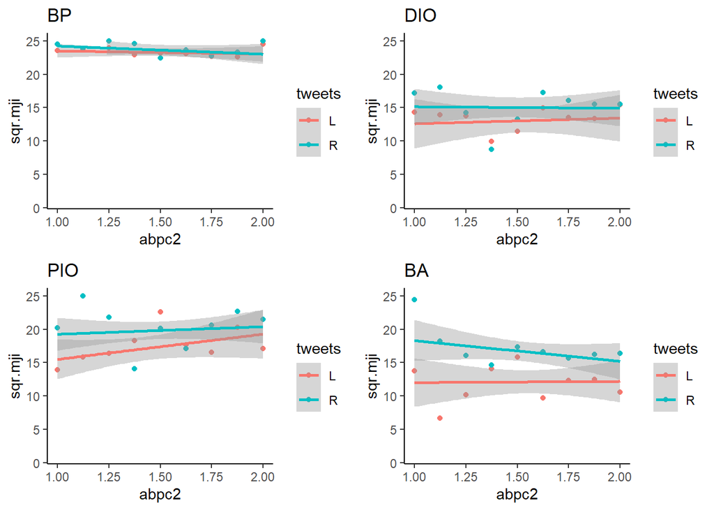

## RIGHT of midpoint (ABPC > 2) w/ ABPC factor 2 (RT)

- Full cases =693
- BA cases =172
- PIO cases =181
- DIO cases =174
- BP cases =166

### Full model

```
##
## Call:
## lm(formula = sqr.mji ~ abpc * PI * DI * tweets, data = subset(dat,
##     abpc.rt >= med.abpc.rt))
##
## Residuals:
##     Min      1Q  Median      3Q     Max
## -15.688  -3.767   1.109   3.562  11.918
##
## Coefficients:
##                      Estimate Std. Error t value Pr(>|t|)
## (Intercept)          11.49698    2.34178   4.909 1.15e-06 ***
## abpc                  1.17775    0.83093   1.417    0.157
## PI1                  -0.29914    3.51051  -0.085    0.932
## DI1                   1.91413    3.43536   0.557    0.578
## tweetsR               1.84364    3.52386   0.523    0.601
## abpc:PI1              1.29223    1.26819   1.019    0.309
## abpc:DI1             -0.58322    1.24332  -0.469    0.639
## PI1:DI1               8.27531    5.11854   1.617    0.106
## abpc:tweetsR         -1.10432    1.26483  -0.873    0.383
## PI1:tweetsR           4.16680    5.17460   0.805    0.421
## DI1:tweetsR          -0.91075    5.17497  -0.176    0.860
## abpc:PI1:DI1         -1.05635    1.85908  -0.568    0.570
## abpc:PI1:tweetsR     -1.52775    1.86146  -0.821    0.412
## abpc:DI1:tweetsR      0.09318    1.88737   0.049    0.961
## PI1:DI1:tweetsR      -2.98558    7.38628  -0.404    0.686
## abpc:PI1:DI1:tweetsR  1.80902    2.67485   0.676    0.499
## ---
## Signif. codes:  0 '***' 0.001 '**' 0.01 '*' 0.05 '.' 0.1 ' ' 1
##
## Residual standard error: 5.67 on 677 degrees of freedom
## Multiple R-squared:  0.3301, Adjusted R-squared:  0.3152
## F-statistic: 22.24 on 15 and 677 DF,  p-value: < 2.2e-16
```

### Regression Coefficients

```
##
## Call:
## lm(formula = sqr.mji ~ abpc * PI * DI * tweets, data = subset(dat,
##     abpc.rt >= med.abpc.rt))
##
## Standardized Coefficients::
##          (Intercept)                 abpc                  PI1
##                   NA           0.11219426          -0.02184399
##                  DI1              tweetsR             abpc:PI1
##           0.13974191           0.13456549           0.26960827
##             abpc:DI1              PI1:DI1         abpc:tweetsR
##          -0.12025851           0.51581928          -0.22966778
##          PI1:tweetsR          DI1:tweetsR         abpc:PI1:DI1
##           0.26537996          -0.05734408          -0.18582988
##     abpc:PI1:tweetsR     abpc:DI1:tweetsR      PI1:DI1:tweetsR
##          -0.27704378           0.01638600          -0.14996700
## abpc:PI1:DI1:tweetsR
##           0.25776062
```

### BA

```
##
## Call:
## lm(formula = sqr.mji ~ abpc * tweets, data = subset(dat, Cond_int ==
##     "BA" & abpc.rt >= med.abpc.rt))
##
## Residuals:
##      Min       1Q   Median       3Q      Max
## -12.1009  -4.4276   0.6438   4.6543  11.6374
##
## Coefficients:
##              Estimate Std. Error t value Pr(>|t|)
## (Intercept)   11.4970     2.6142   4.398 1.93e-05 ***
## abpc           1.1778     0.9276   1.270    0.206
## tweetsR        2.0098     3.9348   0.511    0.610
## abpc:tweetsR  -1.2184     1.4133  -0.862    0.390
## ---
## Signif. codes:  0 '***' 0.001 '**' 0.01 '*' 0.05 '.' 0.1 ' ' 1
##
## Residual standard error: 6.33 on 168 degrees of freedom
## Multiple R-squared:  0.0201, Adjusted R-squared:  0.002606
## F-statistic: 1.149 on 3 and 168 DF,  p-value: 0.331
```

### Regression Coefficients

```
##
## Call:
## lm(formula = sqr.mji ~ abpc * tweets, data = subset(dat, Cond_int ==
##     "BA" & abpc.rt >= med.abpc.rt))
##
## Standardized Coefficients::
##  (Intercept)         abpc      tweetsR abpc:tweetsR
##           NA    0.1285938    0.1588408   -0.2723209
```

### PIO

```
##
## Call:
## lm(formula = sqr.mji ~ abpc * tweets, data = subset(dat, Cond_int ==
##     "PIO" & abpc.rt >= med.abpc.rt))
##
## Residuals:
##     Min      1Q  Median      3Q     Max
## -15.688  -4.561   1.326   5.664   9.311
##
## Coefficients:
##              Estimate Std. Error t value Pr(>|t|)
## (Intercept)    11.198      2.964   3.778 0.000215 ***
## abpc            2.470      1.086   2.275 0.024101 *
## tweetsR         6.010      4.294   1.400 0.163355
## abpc:tweetsR   -2.632      1.548  -1.701 0.090763 .
## ---
## Signif. codes:  0 '***' 0.001 '**' 0.01 '*' 0.05 '.' 0.1 ' ' 1
##
## Residual standard error: 6.425 on 177 degrees of freedom
## Multiple R-squared:  0.03445,    Adjusted R-squared:  0.01809
## F-statistic: 2.105 on 3 and 177 DF,  p-value: 0.1012
```

### Regression Coefficients

```
##
## Call:
## lm(formula = sqr.mji ~ abpc * tweets, data = subset(dat, Cond_int ==
##     "PIO" & abpc.rt >= med.abpc.rt))
##
## Standardized Coefficients::
##  (Intercept)         abpc      tweetsR abpc:tweetsR
##           NA    0.2362486    0.4626847   -0.5830142
```

### DIO

```
##
## Call:
## lm(formula = sqr.mji ~ abpc * tweets, data = subset(dat, Cond_int ==
##     "DIO" & abpc.rt >= med.abpc.rt))
##
## Residuals:
##      Min       1Q   Median       3Q      Max
## -12.2403  -5.4831  -0.1216   4.7490  11.6980
##
## Coefficients:
##              Estimate Std. Error t value Pr(>|t|)
## (Intercept)   13.4111     2.7677   4.846 2.83e-06 ***
## abpc           0.5945     1.0184   0.584    0.560
## tweetsR        0.6574     4.1706   0.158    0.875
## abpc:tweetsR  -0.8475     1.5401  -0.550    0.583
## ---
## Signif. codes:  0 '***' 0.001 '**' 0.01 '*' 0.05 '.' 0.1 ' ' 1
##
## Residual standard error: 6.244 on 170 degrees of freedom
## Multiple R-squared:  0.01813,    Adjusted R-squared:  0.0008046
## F-statistic: 1.046 on 3 and 170 DF,  p-value: 0.3735
```

### Regression Coefficients

```
##
## Call:
## lm(formula = sqr.mji ~ abpc * tweets, data = subset(dat, Cond_int ==
##     "DIO" & abpc.rt >= med.abpc.rt))
##
## Standardized Coefficients::
##  (Intercept)         abpc      tweetsR abpc:tweetsR
##           NA   0.05914784   0.05242625  -0.18624193
```

### BP

```
##
## Call:
## lm(formula = sqr.mji ~ abpc * tweets, data = subset(dat, Cond_int ==
##     "BP" & abpc.rt >= med.abpc.rt))
##
## Residuals:
##      Min       1Q   Median       3Q      Max
## -11.5774  -0.8819   1.1444   1.2640   2.3294
##
## Coefficients:
##              Estimate Std. Error t value Pr(>|t|)
## (Intercept)   21.3873     1.2672  16.877   <2e-16 ***
## abpc           0.8304     0.4592   1.808   0.0724 .
## tweetsR        2.1141     1.6885   1.252   0.2124
## abpc:tweetsR  -0.7299     0.6058  -1.205   0.2301
## ---
## Signif. codes:  0 '***' 0.001 '**' 0.01 '*' 0.05 '.' 0.1 ' ' 1
##
## Residual standard error: 2.614 on 162 degrees of freedom
## Multiple R-squared:  0.02116,    Adjusted R-squared:  0.003035
## F-statistic: 1.167 on 3 and 162 DF,  p-value: 0.3239
```

### Regression Coefficients

```
##
## Call:
## lm(formula = sqr.mji ~ abpc * tweets, data = subset(dat, Cond_int ==
##     "BP" & abpc.rt >= med.abpc.rt))
##
## Standardized Coefficients::
##  (Intercept)         abpc      tweetsR abpc:tweetsR
##           NA    0.2157473    0.4007860   -0.4055256
```

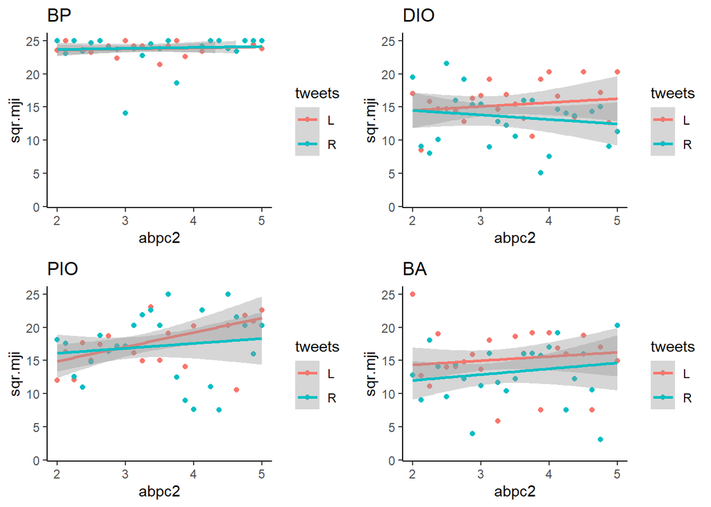

## Left of midpoint (ABPC < 2) w/ ABPC factor 3 (ES)

- Full cases =563
- BA cases =141
- PIO cases =140
- DIO cases =142
- BP cases =140

### Full model

```
##
## Call:
## lm(formula = sqr.mji ~ abpc * PI * DI * tweets, data = subset(dat,
##     abpc.es < med.abpc.es))
##
## Residuals:
##      Min       1Q   Median       3Q      Max
## -12.8203  -3.5929   0.9495   3.2094  13.9558
##
## Coefficients:
##                       Estimate Std. Error t value Pr(>|t|)
## (Intercept)            6.86779    2.46359   2.788  0.00549 **
## abpc                   2.41791    1.25488   1.927  0.05452 .
## PI1                    5.68499    3.41650   1.664  0.09669 .
## DI1                    6.09115    3.82207   1.594  0.11159
## tweetsR               17.04761    3.91176   4.358 1.57e-05 ***
## abpc:PI1               0.09411    1.78922   0.053  0.95807
## abpc:DI1              -2.03676    2.04555  -0.996  0.31983
## PI1:DI1                4.51607    5.54338   0.815  0.41561
## abpc:tweetsR          -6.73482    2.09668  -3.212  0.00139 **
## PI1:tweetsR           -6.17153    5.43470  -1.136  0.25663
## DI1:tweetsR          -14.14926    5.39873  -2.621  0.00901 **
## abpc:PI1:DI1          -0.39886    3.10940  -0.128  0.89798
## abpc:PI1:tweetsR       1.50900    2.95022   0.511  0.60922
## abpc:DI1:tweetsR       5.29651    2.91595   1.816  0.06986 .
## PI1:DI1:tweetsR        4.27393    7.77063   0.550  0.58254
## abpc:PI1:DI1:tweetsR  -0.30918    4.30715  -0.072  0.94280
## ---
## Signif. codes:  0 '***' 0.001 '**' 0.01 '*' 0.05 '.' 0.1 ' ' 1
##
## Residual standard error: 5.366 on 547 degrees of freedom
## Multiple R-squared:  0.391,  Adjusted R-squared:  0.3743
## F-statistic: 23.41 on 15 and 547 DF,  p-value: < 2.2e-16
```

### Regression Coefficients

```
##
## Call:
## lm(formula = sqr.mji ~ abpc * PI * DI * tweets, data = subset(dat,
##     abpc.es < med.abpc.es))
##
## Standardized Coefficients::
##          (Intercept)                 abpc                  PI1
##                   NA           0.15960740           0.41940698
##                  DI1              tweetsR             abpc:PI1
##           0.44937709           1.25769465           0.01278329
##             abpc:DI1              PI1:DI1         abpc:tweetsR
##          -0.27844247           0.28802405          -0.93856021
##          PI1:tweetsR          DI1:tweetsR         abpc:PI1:DI1
##          -0.38270743          -0.90023979          -0.04493681
##     abpc:PI1:tweetsR     abpc:DI1:tweetsR      PI1:DI1:tweetsR
##           0.17238603           0.63736641           0.20286689
## abpc:PI1:DI1:tweetsR
##          -0.02735216
```

### BA

```
##
## Call:
## lm(formula = sqr.mji ~ abpc * tweets, data = subset(dat, Cond_int ==
##     "BA" & abpc.es < med.abpc.es))
##
## Residuals:
##      Min       1Q   Median       3Q      Max
## -11.2816  -3.9149  -0.5897   3.7102  13.9558
##
## Coefficients:
##              Estimate Std. Error t value Pr(>|t|)
## (Intercept)     6.868      2.696   2.547 0.011971 *
## abpc            2.418      1.373   1.760 0.080570 .
## tweetsR        17.048      4.282   3.982 0.000111 ***
## abpc:tweetsR   -6.735      2.295  -2.935 0.003916 **
## ---
## Signif. codes:  0 '***' 0.001 '**' 0.01 '*' 0.05 '.' 0.1 ' ' 1
##
## Residual standard error: 5.873 on 137 degrees of freedom
## Multiple R-squared:   0.19,  Adjusted R-squared:  0.1722
## F-statistic: 10.71 on 3 and 137 DF,  p-value: 2.275e-06
```

### Regression Coefficients

```
##
## Call:
## lm(formula = sqr.mji ~ abpc * tweets, data = subset(dat, Cond_int ==
##     "BA" & abpc.es < med.abpc.es))
##
## Standardized Coefficients::
##  (Intercept)         abpc      tweetsR abpc:tweetsR
##           NA    0.1702952    1.3154797   -0.9634699
```

### PIO

```
##
## Call:
## lm(formula = sqr.mji ~ abpc * tweets, data = subset(dat, Cond_int ==
##     "PIO" & abpc.es < med.abpc.es))
##
## Residuals:
##      Min       1Q   Median       3Q      Max
## -12.8203  -5.1302   0.7577   5.2101   9.3262
##
## Coefficients:
##              Estimate Std. Error t value Pr(>|t|)
## (Intercept)    12.553      2.649   4.738 5.37e-06 ***
## abpc            2.512      1.427   1.760   0.0807 .
## tweetsR        10.876      4.223   2.576   0.0111 *
## abpc:tweetsR   -5.226      2.323  -2.250   0.0261 *
## ---
## Signif. codes:  0 '***' 0.001 '**' 0.01 '*' 0.05 '.' 0.1 ' ' 1
##
## Residual standard error: 6.006 on 136 degrees of freedom
## Multiple R-squared:  0.05459,    Adjusted R-squared:  0.03374
## F-statistic: 2.618 on 3 and 136 DF,  p-value: 0.05353
```

### Regression Coefficients

```
##
## Call:
## lm(formula = sqr.mji ~ abpc * tweets, data = subset(dat, Cond_int ==
##     "PIO" & abpc.es < med.abpc.es))
##
## Standardized Coefficients::
##  (Intercept)         abpc      tweetsR abpc:tweetsR
##           NA    0.1862250    0.8887658   -0.7826107
```

### DIO

```
##
## Call:
## lm(formula = sqr.mji ~ abpc * tweets, data = subset(dat, Cond_int ==
##     "DIO" & abpc.es < med.abpc.es))
##
## Residuals:
##     Min      1Q  Median      3Q     Max
## -11.109  -4.747  -0.129   4.538  11.674
##
## Coefficients:
##              Estimate Std. Error t value Pr(>|t|)
## (Intercept)   12.9589     3.3255   3.897 0.000151 ***
## abpc           0.3811     1.8384   0.207 0.836063
## tweetsR        2.8983     4.2345   0.684 0.494828
## abpc:tweetsR  -1.4383     2.3063  -0.624 0.533886
## ---
## Signif. codes:  0 '***' 0.001 '**' 0.01 '*' 0.05 '.' 0.1 ' ' 1
##
## Residual standard error: 6.107 on 138 degrees of freedom
## Multiple R-squared:  0.005129,   Adjusted R-squared:  -0.0165
## F-statistic: 0.2372 on 3 and 138 DF,  p-value: 0.8703
```

### Regression Coefficients

```
##
## Call:
## lm(formula = sqr.mji ~ abpc * tweets, data = subset(dat, Cond_int ==
##     "DIO" & abpc.es < med.abpc.es))
##
## Standardized Coefficients::
##  (Intercept)         abpc      tweetsR abpc:tweetsR
##           NA   0.02919184   0.24001098  -0.23286058
```

### BP

```
##
## Call:
## lm(formula = sqr.mji ~ abpc * tweets, data = subset(dat, Cond_int ==
##     "BP" & abpc.es < med.abpc.es))
##
## Residuals:
##      Min       1Q   Median       3Q      Max
## -11.6455  -0.7242   1.0947   1.6872   1.7544
##
## Coefficients:
##              Estimate Std. Error t value Pr(>|t|)
## (Intercept)   23.1600     1.6161  14.331   <2e-16 ***
## abpc           0.0764     0.9787   0.078    0.938
## tweetsR        1.0007     2.0547   0.487    0.627
## abpc:tweetsR  -0.2385     1.1940  -0.200    0.842
## ---
## Signif. codes:  0 '***' 0.001 '**' 0.01 '*' 0.05 '.' 0.1 ' ' 1
##
## Residual standard error: 2.674 on 136 degrees of freedom
## Multiple R-squared:  0.01264,    Adjusted R-squared:  -0.009144
## F-statistic: 0.5802 on 3 and 136 DF,  p-value: 0.629
```

### Regression Coefficients

```
##
## Call:
## lm(formula = sqr.mji ~ abpc * tweets, data = subset(dat, Cond_int ==
##     "BP" & abpc.es < med.abpc.es))
##
## Standardized Coefficients::
##  (Intercept)         abpc      tweetsR abpc:tweetsR
##           NA   0.01187101   0.18835018  -0.08574779
```

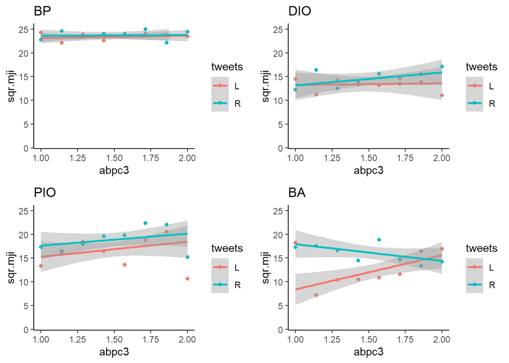

## RIGHT of midpoint (ABPC > 2) w/ ABPC factor 3 (ES)

- Full cases =723
- BA cases =179
- PIO cases =184
- DIO cases =180
- BP cases =180

### Full model

```
##
## Call:
## lm(formula = sqr.mji ~ abpc * PI * DI * tweets, data = subset(dat,
##     abpc.es >= med.abpc.es))
##
## Residuals:
##     Min      1Q  Median      3Q     Max
## -16.106  -3.709   1.183   3.960  12.220
##
## Coefficients:
##                       Estimate Std. Error t value Pr(>|t|)
## (Intercept)           15.12345    2.30524   6.560 1.04e-10 ***
## abpc                   0.16645    0.83320   0.200   0.8417
## PI1                   -1.12026    3.46373  -0.323   0.7465
## DI1                   -3.20905    3.33395  -0.963   0.3361
## tweetsR               -0.05141    3.39849  -0.015   0.9879
## abpc:PI1               1.11723    1.25747   0.888   0.3746
## abpc:DI1               1.06085    1.22268   0.868   0.3859
## PI1:DI1               11.12559    4.96995   2.239   0.0255 *
## abpc:tweetsR          -0.53317    1.23340  -0.432   0.6657
## PI1:tweetsR            8.39042    4.87461   1.721   0.0856 .
## DI1:tweetsR            6.85307    4.98076   1.376   0.1693
## abpc:PI1:DI1          -1.69257    1.82074  -0.930   0.3529
## abpc:PI1:tweetsR      -2.38067    1.77412  -1.342   0.1801
## abpc:DI1:tweetsR      -2.65317    1.84094  -1.441   0.1500
## PI1:DI1:tweetsR      -13.72689    7.05105  -1.947   0.0520 .
## abpc:PI1:DI1:tweetsR   5.02726    2.58668   1.944   0.0524 .
## ---
## Signif. codes:  0 '***' 0.001 '**' 0.01 '*' 0.05 '.' 0.1 ' ' 1
##
## Residual standard error: 5.745 on 707 degrees of freedom
## Multiple R-squared:  0.3066, Adjusted R-squared:  0.2919
## F-statistic: 20.84 on 15 and 707 DF,  p-value: < 2.2e-16
```

### Regression Coefficients

```
##
## Call:
## lm(formula = sqr.mji ~ abpc * PI * DI * tweets, data = subset(dat,
##     abpc.es >= med.abpc.es))
##
## Standardized Coefficients::
##          (Intercept)                 abpc                  PI1
##                   NA          0.016292878         -0.082103689
##                  DI1              tweetsR             abpc:PI1
##         -0.235189997         -0.003767543          0.231817791
##             abpc:DI1              PI1:DI1         abpc:tweetsR
##          0.217120555          0.705186167         -0.109997600
##          PI1:tweetsR          DI1:tweetsR         abpc:PI1:DI1
##          0.545836081          0.433566651         -0.299062093
##     abpc:PI1:tweetsR     abpc:DI1:tweetsR      PI1:DI1:tweetsR
##         -0.432968105         -0.462286043         -0.694641482
## abpc:PI1:DI1:tweetsR
##          0.713973139
```

### BA

```
##
## Call:
## lm(formula = sqr.mji ~ abpc * tweets, data = subset(dat, Cond_int ==
##     "BA" & abpc.es >= med.abpc.es))
##
## Residuals:
##      Min       1Q   Median       3Q      Max
## -12.5050  -5.0376   0.4831   4.5702  11.4450
##
## Coefficients:
##              Estimate Std. Error t value Pr(>|t|)
## (Intercept)  15.12345    2.54228   5.949 1.44e-08 ***
## abpc          0.16645    0.91887   0.181    0.856
## tweetsR       0.09739    3.74890   0.026    0.979
## abpc:tweetsR -0.63632    1.36150  -0.467    0.641
## ---
## Signif. codes:  0 '***' 0.001 '**' 0.01 '*' 0.05 '.' 0.1 ' ' 1
##
## Residual standard error: 6.335 on 175 degrees of freedom
## Multiple R-squared:  0.01736,    Adjusted R-squared:  0.0005173
## F-statistic: 1.031 on 3 and 175 DF,  p-value: 0.3804
```

### Regression Coefficients

```
##
## Call:
## lm(formula = sqr.mji ~ abpc * tweets, data = subset(dat, Cond_int ==
##     "BA" & abpc.es >= med.abpc.es))
##
## Standardized Coefficients::
##  (Intercept)         abpc      tweetsR abpc:tweetsR
##           NA  0.018396134  0.007704532 -0.142007022
```

### PIO

```
##
## Call:
## lm(formula = sqr.mji ~ abpc * tweets, data = subset(dat, Cond_int ==
##     "PIO" & abpc.es >= med.abpc.es))
##
## Residuals:
##     Min      1Q  Median      3Q     Max
## -16.106  -5.458   1.552   5.522   9.080
##
## Coefficients:
##              Estimate Std. Error t value Pr(>|t|)
## (Intercept)    14.003      2.996   4.673 5.79e-06 ***
## abpc            1.284      1.092   1.176   0.2412
## tweetsR         8.339      4.050   2.059   0.0410 *
## abpc:tweetsR   -2.914      1.478  -1.971   0.0502 .
## ---
## Signif. codes:  0 '***' 0.001 '**' 0.01 '*' 0.05 '.' 0.1 ' ' 1
##
## Residual standard error: 6.659 on 180 degrees of freedom
## Multiple R-squared:  0.02402,    Adjusted R-squared:  0.007754
## F-statistic: 1.477 on 3 and 180 DF,  p-value: 0.2224
```

### Regression Coefficients

```
##
## Call:
## lm(formula = sqr.mji ~ abpc * tweets, data = subset(dat, Cond_int ==
##     "PIO" & abpc.es >= med.abpc.es))
##
## Standardized Coefficients::
##  (Intercept)         abpc      tweetsR abpc:tweetsR
##           NA    0.1284462    0.6251217   -0.6170841
```

### DIO

```
##
## Call:
## lm(formula = sqr.mji ~ abpc * tweets, data = subset(dat, Cond_int ==
##     "DIO" & abpc.es >= med.abpc.es))
##
## Residuals:
##      Min       1Q   Median       3Q      Max
## -13.1831  -5.4680   0.4834   4.7742  11.9860
##
## Coefficients:
##              Estimate Std. Error t value Pr(>|t|)
## (Intercept)    11.914      2.686   4.435 1.62e-05 ***
## abpc            1.227      0.998   1.230   0.2204
## tweetsR         6.494      4.058   1.600   0.1113
## abpc:tweetsR   -3.007      1.521  -1.977   0.0496 *
## ---
## Signif. codes:  0 '***' 0.001 '**' 0.01 '*' 0.05 '.' 0.1 ' ' 1
##
## Residual standard error: 6.407 on 176 degrees of freedom
## Multiple R-squared:  0.03156,    Adjusted R-squared:  0.01506
## F-statistic: 1.912 on 3 and 176 DF,  p-value: 0.1293
```

### Regression Coefficients

```
##
## Call:
## lm(formula = sqr.mji ~ abpc * tweets, data = subset(dat, Cond_int ==
##     "DIO" & abpc.es >= med.abpc.es))
##
## Standardized Coefficients::
##  (Intercept)         abpc      tweetsR abpc:tweetsR
##           NA    0.1209228    0.5012054   -0.6283241
```

### BP

```
##
## Call:
## lm(formula = sqr.mji ~ abpc * tweets, data = subset(dat, Cond_int ==
##     "BP" & abpc.es >= med.abpc.es))
##
## Residuals:
##     Min      1Q  Median      3Q     Max
## -11.499  -1.017   1.220   1.362   2.132
##
## Coefficients:
##              Estimate Std. Error t value Pr(>|t|)
## (Intercept)   21.9197     1.1564  18.956   <2e-16 ***
## abpc           0.6520     0.4252   1.533    0.127
## tweetsR        1.4652     1.5684   0.934    0.351
## abpc:tweetsR  -0.5398     0.5698  -0.947    0.345
## ---
## Signif. codes:  0 '***' 0.001 '**' 0.01 '*' 0.05 '.' 0.1 ' ' 1
##
## Residual standard error: 2.529 on 176 degrees of freedom
## Multiple R-squared:  0.01376,    Adjusted R-squared:  -0.003046
## F-statistic: 0.8188 on 3 and 176 DF,  p-value: 0.4851
```

### Regression Coefficients

```
##
## Call:
## lm(formula = sqr.mji ~ abpc * tweets, data = subset(dat, Cond_int ==
##     "BP" & abpc.es >= med.abpc.es))
##
## Standardized Coefficients::
##  (Intercept)         abpc      tweetsR abpc:tweetsR
##           NA    0.1727090    0.2891751   -0.3080208
```

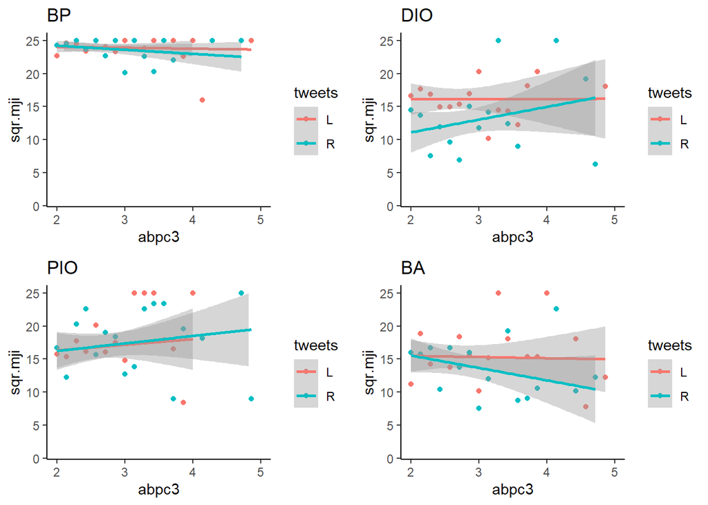